# P07_github

World Income Distribution  
Prédiction de revenus

Ce projet se dessine autour des consignes disponibles sur [le lien suivant](https://bertrand4.github.io/Prediction_de_revenus/contexte).  
Des rappels en seront faits tout au long du rapport, afin d'en faciliter la lecture.

[Ulysse Vital NANGBE](https://www.linkedin.com/in/ulysse-vital-nangbe-18526772/), Data Scientist, Mentor  
[Antony Morello](https://www.linkedin.com/in/antony-morello/), Data Analyst

**Scénario**  
Vous êtes employé dans une banque, présente dans de nombreux pays à travers le monde.  
Vous devez cibler de nouveaux clients potentiels, plus particulièrement les jeunes en âge d'ouvrir leur tout premier compte bancaire.  
Vous ne disposez que des informations suivantes dans un csv, téléchargeable sur le [ce premier lien](https://s3-eu-west-1.amazonaws.com/static.oc-static.com/prod/courses/files/parcours-data-analyst/data-projet7.csv). Sur ce [ce second lien](https://data.worldbank.org/indicator/SI.POV.GINI), vous pourrez trouver beaucoup d'informations de la **World Bank** comme les indices de Gini et d'autres données économiques nationales.  
Au global, notre intérêt se porte sur les informations suivantes :

1. le revenu des parents
2. le revenu moyen du pays dans lequel habite le prospect
3. l'indice de Gini calculé sur les revenus des habitants du pays en question

La démarche se déroulera en **quatre missions**, détaillées le long du notebook pour vous accompagner dans la lecture.

Sommaire

Mission 1 : Descriptif rapide des données

Info

Describe

Year_survey

Quantile

Income

Gdpppp

Population mondiale et échantillon

Mission 3 : Classifications des revenus

1. Génération $Y_{parents}$
2. Génération $\epsilon$
3. Calcul $Y_{child}$ avec p=0.9
4. Calcul $c_{i,child}$ et $c_{i,parents}$
5. Calcul des probabilités conditionnelles
6. Réplication des 500 clones
7. Calcul des $c_{i,parents}$ finaux

Mission 2 : Clustering et profils de revenus

1. Revenus Moyens
2. Indices de Gini
3. Classifications géo-économiques
4. Classification Hiérarchique Ascendante
5. K-means
6. Sélection finale
7. Classements globaux des Ginis

Mission 4 : Tests statistiques

1. ANOVA

données non-log & log

2. Régression linéaire 1

données non-log & log

3. Régression linéaire 2

données non-log & log

4. Essai sans conclusion

**Importations des données et déclaration des variables**

```python
import numpy as np
import pandas as pd
import matplotlib as mpl
import matplotlib.pyplot as plt
import seaborn as sns
import scipy.stats as st

pd.set_option('display.max_columns', None)

source = r"F:\09 - Data Analyst\02 - Projets\07 - Projet 7\01 - Données source"

save = r"F:\09 - Data Analyst\02 - Projets\07 - Projet 7\02 - viz_prez"
#data
data = pd.read_csv(source + r"\data-projet7.csv", sep=",", decimal = ",")

# indices de gini AVEC NaN
data_gini = pd.read_csv(source + r"\data-projet7-gini.csv", skiprows = 4, decimal = ".", sep=",")
data_gini["Indicator Name"] = "Gini"

# indices de gini SANS NaN
data_gini_snan = pd.read_csv(source + r"\data-projet7-gini.csv", skiprows = 4, decimal = ".", sep=",", keep_default_na=True)
data_gini_snan["Indicator Name"] = "Gini"

# populations mondiales
data_pop_monde = pd.read_csv(source + r"\data-projet7-pop_monde.csv",skiprows = 4, sep = ",")
data_pop_monde["Indicator Name"] = "pop_monde"

# gdp en $PPP par pays
data_gdpppp_pays = pd.read_csv(source + r"\data-projet7-gdp_ppp.csv",skiprows = 4, sep = ",")
data_gdpppp_pays["Indicator Name"] = "gdp_ppp"

# gdp_per_capita en $PPP par pays
data_gdpppp_pays_capita = pd.read_csv(source + r"\data-projet7-gdpppp.csv",skiprows = 4, sep = ",")
data_gdpppp_pays_capita["Indicator Name"] = "gdp_ppp_capita"

# classification par income et géographie des pays
table_pays = pd.read_csv(source + r"\data-projet7-table-pays.csv", sep=",")

from IPython.core.display import display, Markdown, Latex, HTML
import warnings

warnings.filterwarnings('ignore')
HTML("""<style> {text-align: center; vertical-align: middle} </style>""")
```

**Mission 1 : Descriptif rapide des données**  
**Consignes brèves**  
Résumez les données utilisées :

1. année(s) des données utilisées
2. nombre de pays présents
3. population couverte par l'analyse

**Méthode**  
Je commence la description brève et le nettoyage de mes données selon la méthode suivante :

- étude des types de variables
- analyse univariée brève de tout mon tableau
- analyse et traitement colonne par colonne

Je commence par une vue rapide et globale de mon dataframe et de ses variables.

**1.1 Info**

Retour au sommaire

```python
data
```

|  | country | year_survey | quantile | nb_quantiles | income | gdpppp |
| --- | --- | --- | --- | --- | --- | --- |
| 0 | ALB | 2008 | 1 | 100 | 728.89795 | 7297.00000 |
| 1 | ALB | 2008 | 2 | 100 | 916.66235 | 7297.00000 |
| 2 | ALB | 2008 | 3 | 100 | 1010.91600 | 7297.00000 |
| 3 | ALB | 2008 | 4 | 100 | 1086.90780 | 7297.00000 |
| 4 | ALB | 2008 | 5 | 100 | 1132.69970 | 7297.00000 |
| ... | ... | ... | ... | ... | ... | ... |
| 11594 | COD | 2008 | 96 | 100 | 810.62330 | 303.19305 |
| 11595 | COD | 2008 | 97 | 100 | 911.78340 | 303.19305 |
| 11596 | COD | 2008 | 98 | 100 | 1057.80740 | 303.19305 |
| 11597 | COD | 2008 | 99 | 100 | 1286.60290 | 303.19305 |
| 11598 | COD | 2008 | 100 | 100 | 2243.12260 | 303.19305 |

11599 rows × 6 columns

```python
data.info()
```

```
<class 'pandas.core.frame.DataFrame'>
RangeIndex: 11599 entries, 0 to 11598
Data columns (total 6 columns):
 #   Column        Non-Null Count  Dtype
---  ------        --------------  -----
 0   country       11599 non-null  object
 1   year_survey   11599 non-null  int64
 2   quantile      11599 non-null  int64
 3   nb_quantiles  11599 non-null  int64
 4   income        11599 non-null  float64
 5   gdpppp        11399 non-null  float64
dtypes: float64(2), int64(3), object(1)
memory usage: 543.8+ KB
```

Mon dataframe comporte six colonnes :

- Une qualitative
  - country : le nom du pays
- cinq quantitatives
  - year_survey : l'année du sondage associé au pays (**country**)
  - quantile : le quantile associé au niveau de revenu **income**
  - nb_quantiles : le nombre de quantile échantillonné associé au pays (**country**)
  - income : le niveau de revenu associé au **quantile**
  - gdpppp : le PIB/habitant en PPP associé au pays (**country**)

Le Dtype object dans la colonne **country** regroupe des chaines de caractères. J'unifie le type de données s'y trouvant, bien que cela n'en change pas le Dtype.

```python
data.country = [str(x) for x in data.country]
```

```python
data.info()
```

```
<class 'pandas.core.frame.DataFrame'>
RangeIndex: 11599 entries, 0 to 11598
Data columns (total 6 columns):
 #   Column        Non-Null Count  Dtype
---  ------        --------------  -----
 0   country       11599 non-null  object
 1   year_survey   11599 non-null  int64
 2   quantile      11599 non-null  int64
 3   nb_quantiles  11599 non-null  int64
 4   income        11599 non-null  float64
 5   gdpppp        11399 non-null  float64
dtypes: float64(2), int64(3), object(1)
memory usage: 543.8+ KB
```

Maintenant que les types de variables sont fixés, je regarde une brève description univariée de mon dataframe.

**1.2 Describe**

Retour au sommaire

```python
data.describe()
```

|  | year_survey | quantile | nb_quantiles | income | gdpppp |
| --- | --- | --- | --- | --- | --- |
| count | 11599.000000 | 11599.000000 | 11599.0 | 11599.000000 | 1.139900e+04 |
| mean | 2007.982757 | 50.500819 | 100.0 | 6069.224260 | 5.022128e+04 |
| std | 0.909633 | 28.868424 | 0.0 | 9414.185972 | 4.000688e+05 |
| min | 2004.000000 | 1.000000 | 100.0 | 16.719418 | 3.031931e+02 |
| 25% | 2008.000000 | 25.500000 | 100.0 | 900.685515 | 2.576000e+03 |
| 50% | 2008.000000 | 51.000000 | 100.0 | 2403.244900 | 7.560000e+03 |
| 75% | 2008.000000 | 75.500000 | 100.0 | 7515.420900 | 1.877300e+04 |
| max | 2011.000000 | 100.000000 | 100.0 | 176928.550000 | 4.300332e+06 |

Nous avons ici une moyenne globale des revenus de 6 069.22 PPP.  
Il semblerait qu'il y ait un problème de GDP PPP. Le max de la colonne **gdpppp** est de 4 300 332. Un pays aurait donc un GDP/hbt en PPP de + de 4 millions. C'est une erreur. Nous allons voir ce point plus bas dans la section gdpppp.  
Je me penche à présent sur l'étude et la correction de chacune de mes colonnes à la suite :

- year_survey
- quantile
- nb_quantile
- income
- gdpppp

**1.3 Year_survey**

Retour au sommaire

```python
# Nombre de pays par années
data.groupby(["year_survey"]).nunique().country
```

```
year_survey
2004     1
2006     5
2007    15
2008    76
2009    12
2010     6
2011     1
Name: country, dtype: int64
```

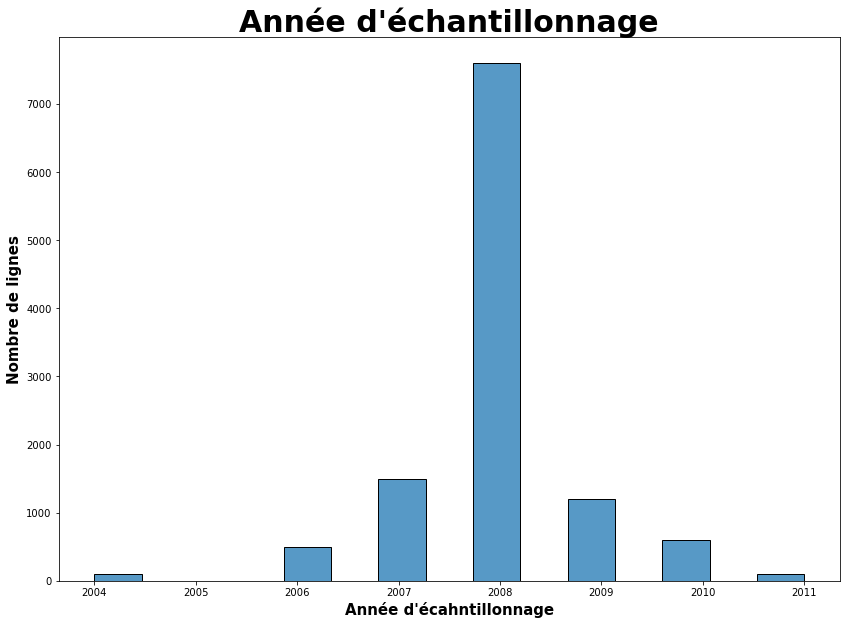

```python
plt.figure(figsize = (14,10))

sns.histplot(data = data, x = "year_survey")
plt.xticks(ha = "center")
plt.xlabel("Année d'écahntillonnage", fontweight = "bold", fontsize = 15)
plt.ylabel("Nombre de lignes", fontweight = "bold", fontsize = 15)
plt.title("Année d'échantillonnage", fontweight = "bold", fontsize = 30)

plt.savefig(save + r"\01_histo_années.png")

plt.show()
```

La majorité de mes dates d'échantillonnage sont en 2008, puis en 2007, 2009, 2010, 2006, 2011 et 2004.  
La distribution a une allure normale avec une moyenne de 2007.98, en 2008 donc.  
Penchons-nous sur les quantiles :

**1.4 Quantile**

Retour au sommaire

```python
# nombre de pays
len(data.groupby('country').mean())
```

```
116
```

```python
# nombre de lignes
len(data)
```

```
11599
```

Avec 116 pays à 100 centiles, nous observons seulement 11 599 lignes contre nos attentes à 11 600 lignes. Une ligne est manquante. Laquelle ?

En agrégeant mon tableau par quantiles avec un simple décompte, je devrais obtenir 116 à chaque quantile (puisque tous les pays sont supposés en avoir 100). Ensuite, en filtrant sur les quantiles dont les comptes ne sont pas à 116, nous obtiendrons les distorsions (manquants ou doublons).

```python
data.groupby('quantile').count()[data.groupby('quantile').count()["country"] != 116]
```

| quantile | country | year_survey | nb_quantiles | income | gdpppp |
| --- | --- | --- | --- | --- | --- |
| 41 | 115 | 115 | 115 | 115 | 113 |

**Problème de centile** : le 41ème centile d'un de mes pays est manquant. **De quel pays s'agit-il ?**  
En agrégeant mon tableau par paysavec une simple somme des valeurs aggrégées, je devrais obtenir, pour chaque pays, 10 000 dans son champs **nb_quantiles** (100 * 100). Je regarde donc pour quel pays nnous n'observons pas 10 000.

```python
data.groupby('country').sum()[data.groupby('country').sum()['nb_quantiles'] != 10000]
```

| country | year_survey | quantile | nb_quantiles | income | gdpppp |
| --- | --- | --- | --- | --- | --- |
| LTU | 198792 | 5009 | 9900 | 657483.5158 | 1739529.0 |

Le 41ème centile lithuanien est manquant.  
J'ai l'intention de rajouter une ligne avec le même **gdpppp**, mais en y insérant un **income** égal à la moyenne arithmétique entre le centile 40 et 42.

```python
q41 = data[data.country == "LTU"][data[data.country == "LTU"]["quantile"].isin(['40', '41', '42'])].mean()
q41
```

```
year_survey      2008.00000
quantile           41.00000
nb_quantiles      100.00000
income           4882.14065
gdpppp          17571.00000
dtype: float64
```

Maintenant que j'ai stocké dans **q41** mon nouveau quantile 41 lithuanien, je l'insère dans mon dataframe global avec un data.append().

```python
data = data.append(pd.DataFrame([[data[(data.country == "LTU") & (data["quantile"] == 42)].iloc[0,0], int(q41[0]), int(q41[1]), int(q41[2]), float(q41[3]), float(q41[4])]],
                                columns = data.columns),
                   ignore_index = True).sort_values(["country", "quantile"])

del q41
data = data.reset_index(drop = True)
data
```

|  | country | year_survey | quantile | nb_quantiles | income | gdpppp |
| --- | --- | --- | --- | --- | --- | --- |
| 0 | ALB | 2008 | 1 | 100 | 728.89795 | 7297.0 |
| 1 | ALB | 2008 | 2 | 100 | 916.66235 | 7297.0 |
| 2 | ALB | 2008 | 3 | 100 | 1010.91600 | 7297.0 |
| 3 | ALB | 2008 | 4 | 100 | 1086.90780 | 7297.0 |
| 4 | ALB | 2008 | 5 | 100 | 1132.69970 | 7297.0 |
| ... | ... | ... | ... | ... | ... | ... |
| 11595 | ZAF | 2008 | 96 | 100 | 24553.56800 | 9602.0 |
| 11596 | ZAF | 2008 | 97 | 100 | 28858.03100 | 9602.0 |
| 11597 | ZAF | 2008 | 98 | 100 | 35750.29000 | 9602.0 |
| 11598 | ZAF | 2008 | 99 | 100 | 46297.31600 | 9602.0 |
| 11599 | ZAF | 2008 | 100 | 100 | 82408.55000 | 9602.0 |

11600 rows × 6 columns

Je vérifie que toutes mes lignes sont présentes dans la Lithuanie.

```python
data[(data.country == "LTU")]
```

|  | country | year_survey | quantile | nb_quantiles | income | gdpppp |
| --- | --- | --- | --- | --- | --- | --- |
| 6200 | LTU | 2008 | 1 | 100 | 566.3453 | 17571.0 |
| 6201 | LTU | 2008 | 2 | 100 | 1147.0587 | 17571.0 |
| 6202 | LTU | 2008 | 3 | 100 | 1490.8408 | 17571.0 |
| 6203 | LTU | 2008 | 4 | 100 | 1746.5715 | 17571.0 |
| 6204 | LTU | 2008 | 5 | 100 | 1842.9542 | 17571.0 |
| ... | ... | ... | ... | ... | ... | ... |
| 6295 | LTU | 2008 | 96 | 100 | 14597.0360 | 17571.0 |
| 6296 | LTU | 2008 | 97 | 100 | 15659.0080 | 17571.0 |
| 6297 | LTU | 2008 | 98 | 100 | 17883.8770 | 17571.0 |
| 6298 | LTU | 2008 | 99 | 100 | 22551.1700 | 17571.0 |
| 6299 | LTU | 2008 | 100 | 100 | 38836.5300 | 17571.0 |

100 rows × 6 columns

Le 41ème centile a été rajouté, le pays LTU dispose de 100 lignes dans le nouveau dataset.

```python
data[(data.country == "LTU") & (data["quantile"].isin(['40', '41', '42']))]
```

|  | country | year_survey | quantile | nb_quantiles | income | gdpppp |
| --- | --- | --- | --- | --- | --- | --- |
| 6239 | LTU | 2008 | 40 | 100 | 4868.45070 | 17571.0 |
| 6240 | LTU | 2008 | 41 | 100 | 4882.14065 | 17571.0 |
| 6241 | LTU | 2008 | 42 | 100 | 4895.83060 | 17571.0 |

Je m'intéresse maintenant à la colonne **income** exprimée en PPP.

**1.5 Income**  
**Définition PPP**  
Parité de Pouvoir d'achat (Purchasing Power Parity): méthode utilisée en économie pour établir une comparaison des pouvoirs d'achats entre pays selon leurs devises respectives. Une simple utilisation des taux de change (FOREX) ne permet pas de prendre en compte les différences de coûts de la vie. Dans notre étude, la parité de pouvoir d'achat (**PPP**) nous permet de prendre en compte l'intensité du coût de la vie dans chaque pays et d'en reporter l'impact sur le niveau de revenu. A titre d'exemple, un salaire de 60k€ annuels à Paris permet d'avoir une qualité de vie équivalente à un salaire de 50k€ annuels à Rome (source non fiable, exemple illustratif). La courbe des salaires s'en trouve donc remodelée lorsqu'elle est transformée en **PPP**. L'OCDE explique ci-dessous, en anglais, par quelle méthode la transformation en PPP est appliquée.

Méthode EKS : A multilateral method developed by O. Elteto, P. Koves and B. Szulc [Schultz] that computes the nth root of the product of all possible Fisher indexes between n countries. It has been used at the detailed heading level to obtain heading parities, and also at the GDP level. EKS has the properties of base-country invariance and transitivity. For more information, clic there : https://stats.oecd.org/glossary/detail.asp?ID=5525

Nous passons maintenant à l'analyse de la colonne.

Retour au sommaire

```python
data.income.describe()
```

```
count     11600.000000
mean       6069.121925
std        9413.786596
min          16.719418
25%         900.768508
50%        2403.492950
75%        7515.313700
max      176928.550000
Name: income, dtype: float64
```

```python
data[(data.income.isna()) | (data.income.isnull() ) ]
```

|  | country | year_survey | quantile | nb_quantiles | income | gdpppp |
| --- | --- | --- | --- | --- | --- | --- |

Il n'y a pas de valeurs NaN, nulles ou aberrantes dans la colonne income

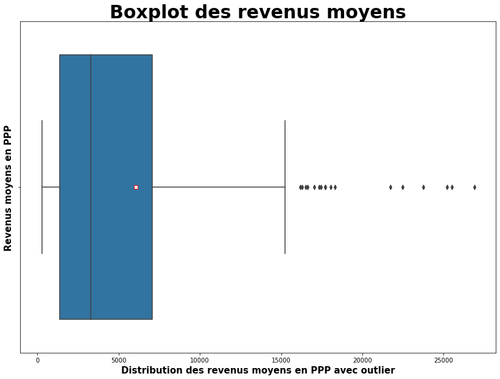

```python
# distribution des revenus moyens
plt.figure(figsize = (14,10))
sns.boxplot(x=data.groupby("country").mean().income,
                orient = "h",
                showfliers = True,
                showmeans = True,
                meanprops={"marker":"s","markerfacecolor":"white", "markeredgecolor":"red"})
plt.title("Boxplot des revenus moyens" , fontsize = 30, fontweight = "bold")
plt.xlabel("Distribution des revenus moyens en PPP avec outlier", fontsize = 15, fontweight = "bold")
plt.ylabel("Revenus moyens en PPP", fontsize = 15, fontweight = "bold")
    #plt.ylabel("Véracité du billet", fontsize = 15, fontweight = "bold")
plt.savefig(save + r"\01_boxplot_income_showfliers.png")
plt.show()
```

L'écart entre la moyenne, la médiane semble indiquer une inégalité entre les différents revenus moyens. En effet, les plus hauts revenus sont nettement supérieurs (notamment post-D9, visibles en pointillés) tirent la moyenne à la hausse. Autrement dit, mes plus hauts centiles, tous pays confondus sont nettement plus élevés que les déciles les plus bas.  
Se pose donc la question des distributions intra-pays : quelles inégalités entre revenus ?  
Se pose la question des inégalités entre pays, des différences de distributions de revenus entre eux.  
Nous nous occupons maintenant de la colonne **gdpppp**

**1.6 GDPPPP**

Retour au sommaire

```python
# pour quels pays mon gdpppp est-il manquant ?
data[(data.gdpppp.isna()) | (data.gdpppp.isnull()) ]
```

|  | country | year_survey | quantile | nb_quantiles | income | gdpppp |
| --- | --- | --- | --- | --- | --- | --- |
| 9000 | PSE | 2009 | 1 | 100 | 195.28990 | NaN |
| 9001 | PSE | 2009 | 2 | 100 | 264.36533 | NaN |
| 9002 | PSE | 2009 | 3 | 100 | 301.44672 | NaN |
| 9003 | PSE | 2009 | 4 | 100 | 329.83392 | NaN |
| 9004 | PSE | 2009 | 5 | 100 | 348.76495 | NaN |
| ... | ... | ... | ... | ... | ... | ... |
| 11395 | XKX | 2008 | 96 | 100 | 5155.36470 | NaN |
| 11396 | XKX | 2008 | 97 | 100 | 5689.52930 | NaN |
| 11397 | XKX | 2008 | 98 | 100 | 6233.73930 | NaN |
| 11398 | XKX | 2008 | 99 | 100 | 7366.67700 | NaN |
| 11399 | XKX | 2008 | 100 | 100 | 7609.57600 | NaN |

200 rows × 6 columns

Nous constatons des PIB/hbt en PPP manquants ci-dessus. Quelle imputation faire pour remplir mon dataset ?  
Il semble inconcevable d'imputer la moyenne arithmétique des autres **gdpppp** présents. Cela ne prendrait pas en compte les inégalités de PIB et de devises.  
Nous recourons à d'autres données de la World Income Distribution, téléchargées sous le nom **data_gdpppp_pays_capita**. Il me donne le PIB/hbt en PPP pays par pays, toutes les années disponibles. Je vais donc extraire la valeur de 2009 pour le pays PSE et la valeur de 2008 pour le pays XKX.

```python
# Pour chaque pays n'ayant pas de gdpppp, je lui impute le gdpppp/hbt qui lui est associé dans le fichier
# data_gdpppp_pays_capita pour la même année d'échantillonnage
for k in data[(data.gdpppp.isna()) | (data.gdpppp.isnull()) ].country.unique():
    annee = int(data[data.country == str(k)].groupby("country").mean().reset_index().year_survey.values)
    data.loc[data[data.country == k].index, "gdpppp"] = float(data_gdpppp_pays_capita[(data_gdpppp_pays_capita["Country Code"]==str(k))][[str(annee)]].values)

# Les deux pays dont les gdpppp_capita m'intéressent
data_gdpppp_pays_capita[data_gdpppp_pays_capita['Country Code'].isin(["PSE", "XKX"])][['2008', '2009']]
```

|  | 2008 | 2009 |
| --- | --- | --- |
| 194 | 3708.664442 | 3951.234993 |
| 259 | 7249.512758 | 7506.875447 |

Je vérifie que mes deux gdpppp moyens aient été imputés avec la bonne date.

```python
# df dont les gdpppp ont été imputés
data[(data.country == "PSE") | (data.country == "XKX")]
```

|  | country | year_survey | quantile | nb_quantiles | income | gdpppp |
| --- | --- | --- | --- | --- | --- | --- |
| 9000 | PSE | 2009 | 1 | 100 | 195.28990 | 3951.234993 |
| 9001 | PSE | 2009 | 2 | 100 | 264.36533 | 3951.234993 |
| 9002 | PSE | 2009 | 3 | 100 | 301.44672 | 3951.234993 |
| 9003 | PSE | 2009 | 4 | 100 | 329.83392 | 3951.234993 |
| 9004 | PSE | 2009 | 5 | 100 | 348.76495 | 3951.234993 |
| ... | ... | ... | ... | ... | ... | ... |
| 11395 | XKX | 2008 | 96 | 100 | 5155.36470 | 7249.512758 |
| 11396 | XKX | 2008 | 97 | 100 | 5689.52930 | 7249.512758 |
| 11397 | XKX | 2008 | 98 | 100 | 6233.73930 | 7249.512758 |
| 11398 | XKX | 2008 | 99 | 100 | 7366.67700 | 7249.512758 |
| 11399 | XKX | 2008 | 100 | 100 | 7609.57600 | 7249.512758 |

200 rows × 6 columns

Nous validons l'imputation.  
Nous regardons maintenant l'allure numérique de notre colonne **gdpppp**.

```python
data.gdpppp.describe()
```

```
count    1.160000e+04
mean     4.944914e+04
std      3.966299e+05
min      3.031931e+02
25%      2.577500e+03
50%      7.532500e+03
75%      1.819625e+04
max      4.300332e+06
Name: gdpppp, dtype: float64
```

Il semblerait que la valeur max de mes gdpppp est trop élevée. Cela sera d'autant plus visibles sur le box-plot suivant.

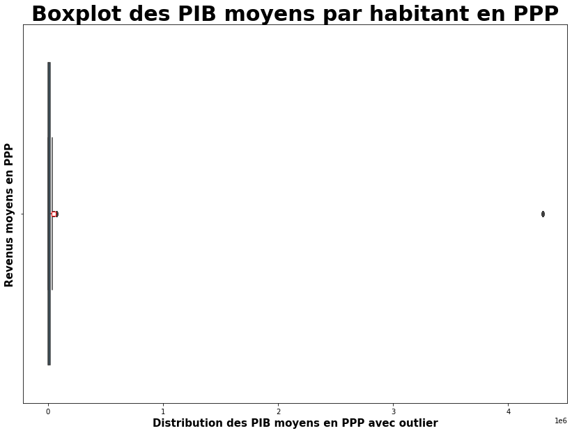

```python
plt.figure(figsize = (14,10))
sns.boxplot(x=data.gdpppp,
                orient = "h",
                showfliers = True,
                showmeans = True,
                meanprops={"marker":"s","markerfacecolor":"white", "markeredgecolor":"red"})
plt.title("Boxplot des PIB moyens par habitant en PPP" , fontsize = 30, fontweight = "bold")
plt.xlabel("Distribution des PIB moyens en PPP avec outlier", fontsize = 15, fontweight = "bold")
plt.ylabel("Revenus moyens en PPP", fontsize = 15, fontweight = "bold")
    #plt.ylabel("Véracité du billet", fontsize = 15, fontweight = "bold")
plt.savefig(save + r"\01_boxplot_gdpppp_showfliers.png")
plt.show()
```

Le boxplot confirme le problème : nous constatons la présence d'une valeur aberrante. Il existerait un pays où le PIB/hbt en ppp serait de 4.3 millions de PPP. C'est inconcevable. Nous réglons le problème en identifiant le pays problématique et en y imputant la bonne valeur.

```python
# pays représentant ce max
str(data[data.gdpppp == data.gdpppp.max()].groupby("country").mean().reset_index().iloc[0,0])
```

```
'FJI'
```

Le problème concerne les îles Fidji.

```python
# année de ce gdpppp
int(data[data.gdpppp == data.gdpppp.max()].groupby("country").mean().reset_index().iloc[0,1])
```

```
2008
```

L'échantillonnage est en 2008.

```python
# gdpppp outlier
"{:,.2f}".format(int(data[data.gdpppp == data.gdpppp.max()].groupby("country").mean().reset_index().iloc[0,5])).replace(",", " ")
```

```
'4 300 332.00'
```

Le GDPPPP aberrant (outlier) est à 4,3 millions de GDPPPP/hbt.  
Je vais maintenant chercher la juste valeur dans le dataset **data_gdpppp_pays_capita** issu de la WDI.

```python
# montant du gdpppp réel selon la WDI
float(data_gdpppp_pays_capita.loc[data_gdpppp_pays_capita[data_gdpppp_pays_capita["Country Code"] == data[data.gdpppp == data.gdpppp.max()].groupby("country").mean().reset_index().iloc[0,0]].index, str(int(data[data.gdpppp == data.gdpppp.max()].groupby("country").mean().reset_index().iloc[0,1]))].values)
```

```
7777.6926915737795
```

Le montant réel du GDPPPP fidjien est de 7 777.69 PPP, d'après la WDI. Cela confirme notre intuition. Nous imputons cette valeur dans notre dataset.

```python
# je remplace dans mon df data le gdpppp
data.loc[data[data.gdpppp == data.gdpppp.max()].index, "gdpppp"] = float(data_gdpppp_pays_capita.loc[data_gdpppp_pays_capita[data_gdpppp_pays_capita["Country Code"] == data[data.gdpppp == data.gdpppp.max()].groupby("country").mean().reset_index().iloc[0,0]].index, str(int(data[data.gdpppp == data.gdpppp.max()].groupby("country").mean().reset_index().iloc[0,1]))].values)
```

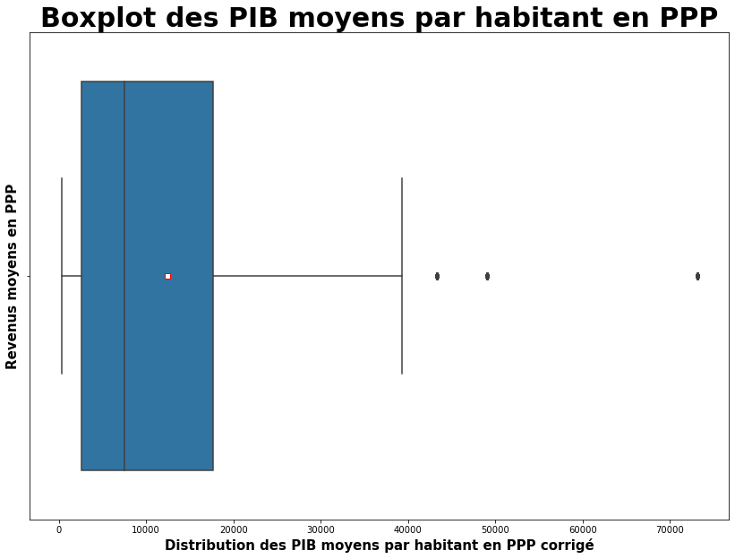

```python
# allure de mes distributions de gdpppp réelles.
plt.figure(figsize = (14,10))
sns.boxplot(x=data.gdpppp,
                orient = "h",
                showfliers = True,
                showmeans = True,
                meanprops={"marker":"s","markerfacecolor":"white", "markeredgecolor":"red"})
plt.title("Boxplot des PIB moyens par habitant en PPP" , fontsize = 30, fontweight = "bold")
plt.xlabel("Distribution des PIB moyens par habitant en PPP corrigé", fontsize = 15, fontweight = "bold")
plt.ylabel("Revenus moyens en PPP", fontsize = 15, fontweight = "bold")
    #plt.ylabel("Véracité du billet", fontsize = 15, fontweight = "bold")
plt.savefig(save + r"\01_boxplot_gdpppp_showfliers_corrected.png")
plt.show()
```

La distribution des PIB/hbt en PPP est plus lisible, bien qu'autant inégalitaire que les revenus (colonne **income**).

Maintenant, nous souhaitons compléter le dataset en y ajoutant, pays par pays, la population en 2008. Bien que certains échantillonnages aient été faits dans une année différente, l'objet de mon étude demeure la distribution des revenus en 2008. Ce choix est une prise de position discutable. Nous associons à une population d'une année (2008) la distribution des revenus d'une potentielle autre année (2011 par exemple). Dans une optique plus rigoureuse, nous aurions imputé, pour chaque pays, sa population de l'année de son échantillonnage. Toutefois, nous comparerions la population et la distribution des revenus d'un pays en 2011 avec les mêmes informations d'un autre pays en 2008.

Les deux méthodes ayant des avantages et inconvénients, nous choisissons de nous en tenir à la population de 2008.

**1.7 Population mondiale et échantillon**

Retour au sommaire

```python
# je conserve les données qui m'intéressent
data_pop_monde = data_pop_monde[["Country Code", "2007", "2008"]]

# je renomme les colonnes
data_pop_monde.columns = [str(x) +"_pop" for x in data_pop_monde.columns]

# allure df
data_pop_monde
```

|  | Country Code_pop | 2007_pop | 2008_pop |
| --- | --- | --- | --- |
| 0 | ABW | 101222.0 | 101358.0 |
| 1 | AFG | 27100536.0 | 27722276.0 |
| 2 | AGO | 20905363.0 | 21695634.0 |
| 3 | ALB | 2970017.0 | 2947314.0 |
| 4 | AND | 82684.0 | 83862.0 |
| ... | ... | ... | ... |
| 259 | XKX | 1733404.0 | 1747383.0 |
| 260 | YEM | 21282515.0 | 21892146.0 |
| 261 | ZAF | 49119766.0 | 49779472.0 |
| 262 | ZMB | 12502958.0 | 12848530.0 |
| 263 | ZWE | 12255922.0 | 12379549.0 |

264 rows × 3 columns

```python
# trouve dans mon df population la ligne WLD et la colonne 2008 ==> population mondiale 2008
"{:,.2f}".format(float(data_pop_monde.loc[data_pop_monde[data_pop_monde['Country Code_pop'] == "WLD"].index.values,"2008_pop"].values)).replace(",", " ")
```

```
'6 757 020 830.00'
```

D'après notre dataset, la population mondiale de 2008 est de 6,8 milliards de personnes. Les informations de la PRB (Population Reference Bureau) convergent vers ce chiffre [dans ce lien](https://www.prb.org/resources/fiche-de-donnees-sur-la-population-mondiale-2008/#:~:text=En%202008%2C%20la%20population%20mondiale,dans%20les%20r%C3%A9gions%20moins%20d%C3%A9velopp%C3%A9es.).

Nous étant assuré de la qualité des données, nous ajoutons à chaque pays sa population en 2008 dans le dataset.

```python
data = data.merge(data_pop_monde[["Country Code_pop", "2008_pop"]],
                  how = 'left',
                  left_on = "country",
                  right_on = "Country Code_pop")
data.drop("Country Code_pop", axis = 1, inplace = True)
data
```

|  | country | year_survey | quantile | nb_quantiles | income | gdpppp | 2008_pop |
| --- | --- | --- | --- | --- | --- | --- | --- |
| 0 | ALB | 2008 | 1 | 100 | 728.89795 | 7297.0 | 2947314.0 |
| 1 | ALB | 2008 | 2 | 100 | 916.66235 | 7297.0 | 2947314.0 |
| 2 | ALB | 2008 | 3 | 100 | 1010.91600 | 7297.0 | 2947314.0 |
| 3 | ALB | 2008 | 4 | 100 | 1086.90780 | 7297.0 | 2947314.0 |
| 4 | ALB | 2008 | 5 | 100 | 1132.69970 | 7297.0 | 2947314.0 |
| ... | ... | ... | ... | ... | ... | ... | ... |
| 11595 | ZAF | 2008 | 96 | 100 | 24553.56800 | 9602.0 | 49779472.0 |
| 11596 | ZAF | 2008 | 97 | 100 | 28858.03100 | 9602.0 | 49779472.0 |
| 11597 | ZAF | 2008 | 98 | 100 | 35750.29000 | 9602.0 | 49779472.0 |
| 11598 | ZAF | 2008 | 99 | 100 | 46297.31600 | 9602.0 | 49779472.0 |
| 11599 | ZAF | 2008 | 100 | 100 | 82408.55000 | 9602.0 | 49779472.0 |

11600 rows × 7 columns

Je vérifie si des valeurs sont manquantes dans mon dataset.

```python
data[data['2008_pop'].isna()]
```

|  | country | year_survey | quantile | nb_quantiles | income | gdpppp | 2008_pop |
| --- | --- | --- | --- | --- | --- | --- | --- |
| 10500 | TWN | 2008 | 1 | 100 | 3477.1800 | 25342.0 | NaN |
| 10501 | TWN | 2008 | 2 | 100 | 4740.2637 | 25342.0 | NaN |
| 10502 | TWN | 2008 | 3 | 100 | 5331.3013 | 25342.0 | NaN |
| 10503 | TWN | 2008 | 4 | 100 | 5761.6577 | 25342.0 | NaN |
| 10504 | TWN | 2008 | 5 | 100 | 6093.2017 | 25342.0 | NaN |
| ... | ... | ... | ... | ... | ... | ... | ... |
| 10595 | TWN | 2008 | 96 | 100 | 38123.4600 | 25342.0 | NaN |
| 10596 | TWN | 2008 | 97 | 100 | 41663.7900 | 25342.0 | NaN |
| 10597 | TWN | 2008 | 98 | 100 | 46650.5820 | 25342.0 | NaN |
| 10598 | TWN | 2008 | 99 | 100 | 54016.9920 | 25342.0 | NaN |
| 10599 | TWN | 2008 | 100 | 100 | 83540.0550 | 25342.0 | NaN |

100 rows × 7 columns

Il manque la population en 2008 de Taïwan. Nous imputons sa population en 2008.  
Daprès le [lien suivant](https://countryeconomy.com/demography/population/taiwan?year=2008), Taïwan dispose de 23,037,000 habitants. Nous imputons cette valeur en dur.

```python
data.loc[data[data['country'] == 'TWN'].index, "2008_pop"] = 23037000
```

```python
# population étudiée
print("Les pays présents dans mon dataset échantillonnent",
      "{:,.2%}".format(data.groupby("country").mean()['2008_pop'].sum() / float(data_pop_monde.loc[data_pop_monde[data_pop_monde['Country Code_pop'] == "WLD"].index.values,"2008_pop"].values)),
      "de la population mondiale, elle-même de",
      "{:,.2f}".format(float(data_pop_monde.loc[data_pop_monde[data_pop_monde['Country Code_pop'] == "WLD"].index.values,"2008_pop"].values)).replace(",", " "),
      "habitants."
     )
```

```
Les pays présents dans mon dataset échantillonnent 91.81% de la population mondiale, elle-même de 6 757 020 830.00 habitants.
```

Nous étudions les revenus à travers des centiles, à savoir les 100 revenus délimitant 100 intervalles, contenant le même nombre de revenus à l'intérieur, pays par pays en PPP. L'échantillonnage en centile permet de résumer l'information de millions de lignes en une centaine de lignes pour chaque pays. Si une partie de l'information est perdue, elle permet toutefois d'en résumer les réalités assez finemenent en proposant 100 classes de revenus différentes ici. Les déciles auraient proposé 10 classes de revenus différentes, perdant trop d'information. Les déciles auraient proposé 1 000 classes de revenus différentes, contenant trop d'informations pour notre étude, compte-tenu du nombre de pays et de la suite du projet.

Notre objectif global : prédire le revenu moyen des futurs actifs de chaque pays en fonction de son :

- revenu moyen
- indice de Gini (mesure d'inégalité des distributions)
- classe de revenu des parents

Pour mettre en place ces prédictions et ces modèles :

- nous calculons les revenus moyens de chaque pays
- nous importons les indices de Gini de chaque pays
- nous déterminons d'éventuels profils types de pays (profil de distribution des revenus) avec deux méthodes simples de clustering

Nous entrons donc dans la seconde mission.  
**Mission 2 : Clustering et profils de revenus**  
**Consigne brève**

1. Montrez la diversité des pays en termes de distribution de revenus à l'aide d'un graphique (axe des ordonnées, sur une échelle logarithmique).
2. Représentez la courbe de Lorenz et l'évolution de l'indice de Gini au fil des ans de chacun des pays choisis.
3. Classez les pays par indice de Gini
4. Donnez la moyenne, les 5 pays ayant l'indice de Gini le plus élevé et les 5 pays ayant l'indice de Gini le plus faible.
5. En quelle position se trouve la France ?

**Méthode**  
Nous calculons et intégrons dans le dataset le premier critère : le revenu moyen de chaque pays.  
Nous modelons le dataset ensuite pour répondre à chaque demande de la mission 02.

**2.1 Revenus moyens**

Je le stocke dans la colonne **income_mean**.

Retour au sommaire

```python
data = data.merge(data.groupby("country").mean().reset_index().rename(columns = {"income" : "income_mean"})[["country", "income_mean"]],
                          how = "left",
                          on = "country")
data
```

|  | country | year_survey | quantile | nb_quantiles | income | gdpppp | 2008_pop | income_mean |
| --- | --- | --- | --- | --- | --- | --- | --- | --- |
| 0 | ALB | 2008 | 1 | 100 | 728.89795 | 7297.0 | 2947314.0 | 2994.829902 |
| 1 | ALB | 2008 | 2 | 100 | 916.66235 | 7297.0 | 2947314.0 | 2994.829902 |
| 2 | ALB | 2008 | 3 | 100 | 1010.91600 | 7297.0 | 2947314.0 | 2994.829902 |
| 3 | ALB | 2008 | 4 | 100 | 1086.90780 | 7297.0 | 2947314.0 | 2994.829902 |
| 4 | ALB | 2008 | 5 | 100 | 1132.69970 | 7297.0 | 2947314.0 | 2994.829902 |
| ... | ... | ... | ... | ... | ... | ... | ... | ... |
| 11595 | ZAF | 2008 | 96 | 100 | 24553.56800 | 9602.0 | 49779472.0 | 5617.904880 |
| 11596 | ZAF | 2008 | 97 | 100 | 28858.03100 | 9602.0 | 49779472.0 | 5617.904880 |
| 11597 | ZAF | 2008 | 98 | 100 | 35750.29000 | 9602.0 | 49779472.0 | 5617.904880 |
| 11598 | ZAF | 2008 | 99 | 100 | 46297.31600 | 9602.0 | 49779472.0 | 5617.904880 |
| 11599 | ZAF | 2008 | 100 | 100 | 82408.55000 | 9602.0 | 49779472.0 | 5617.904880 |

11600 rows × 8 columns

J'importe maintenant les indices de Gini de la WDI, stockés dans le dataset **data_gini**.

**2.2 Indices de Gini**

Retour au sommaire

```python
# je renonce aux indices de gini post-2011
data_gini = data_gini.loc[:,:"2011"]

# je supprime les colonnes remplies de NaN
data_gini.dropna(axis = 1, how = "all", inplace = True)

# je sélectionne les lignes où il existe au moins une valeur non NaN
data_gini = data_gini[data_gini.index.isin(data_gini.iloc[:,4:].dropna(axis = 0, how = "all").index)]

# je remplis mes NaN intermédiaires de gauche à droite, avec la dernière valeur existante à gauche
data_gini.iloc[:,4:] = data_gini.iloc[:,4:].fillna(method = "ffill", axis = 1)

# je remplis mes NaN depuis 1967 de droite à gauche avec la dernière valeur existante à droite
data_gini.iloc[:,4:] = data_gini.iloc[:,4:].fillna(method = "bfill", axis = 1)

# aspect df
data_gini.reset_index(drop = True, inplace = True)
data_gini
```

|  | Country Name | Country Code | Indicator Name | Indicator Code | 1967 | 1969 | 1971 | 1974 | 1975 | 1978 | 1979 | 1980 | 1981 | 1982 | 1983 | 1984 | 1985 | 1986 | 1987 | 1988 | 1989 | 1990 | 1991 | 1992 | 1993 | 1994 | 1995 | 1996 | 1997 | … |
| --- | --- | --- | --- | --- | --- | --- | --- | --- | --- | --- | --- | --- | --- | --- | --- | --- | --- | --- | --- | --- | --- | --- | --- | --- | --- | --- | --- | --- | --- | --- |
| 0 | Angola | AGO | Gini | SI.POV.GINI | 52.0 | 52.0 | 52.0 | 52.0 | 52.0 | 52.0 | 52.0 | 52.0 | 52.0 | 52.0 | 52.0 | 52.0 | 52.0 | 52.0 | 52.0 | 52.0 | 52.0 | 52.0 | 52.0 | 52.0 | 52.0 | 52.0 | 52.0 | 52.0 | 52.0 | … |
| 1 | Albania | ALB | Gini | SI.POV.GINI | 27.0 | 27.0 | 27.0 | 27.0 | 27.0 | 27.0 | 27.0 | 27.0 | 27.0 | 27.0 | 27.0 | 27.0 | 27.0 | 27.0 | 27.0 | 27.0 | 27.0 | 27.0 | 27.0 | 27.0 | 27.0 | 27.0 | 27.0 | 27.0 | 27.0 | … |
| 2 | Argentina | ARG | Gini | SI.POV.GINI | 40.8 | 40.8 | 40.8 | 40.8 | 40.8 | 40.8 | 40.8 | 40.8 | 40.8 | 40.8 | 40.8 | 40.8 | 40.8 | 42.8 | 45.3 | 45.3 | 45.3 | 45.3 | 46.8 | 45.5 | 44.9 | 45.9 | 48.9 | 49.5 | 49.1 | … |
| 3 | Armenia | ARM | Gini | SI.POV.GINI | 36.2 | 36.2 | 36.2 | 36.2 | 36.2 | 36.2 | 36.2 | 36.2 | 36.2 | 36.2 | 36.2 | 36.2 | 36.2 | 36.2 | 36.2 | 36.2 | 36.2 | 36.2 | 36.2 | 36.2 | 36.2 | 36.2 | 36.2 | 36.2 | 36.2 | … |
| 4 | Australia | AUS | Gini | SI.POV.GINI | 31.3 | 31.3 | 31.3 | 31.3 | 31.3 | 31.3 | 31.3 | 31.3 | 31.3 | 31.3 | 31.3 | 31.3 | 32.5 | 32.5 | 32.5 | 32.5 | 33.2 | 33.2 | 33.2 | 33.2 | 33.2 | 33.2 | 32.6 | 32.6 | 32.6 | … |
| ... | ... | ... | ... | ... | ... | ... | ... | ... | ... | ... | ... | ... | ... | ... | ... | ... | ... | ... | ... | ... | ... | ... | ... | ... | ... | ... | ... | ... | ... | … |
| 154 | Kosovo | XKX | Gini | SI.POV.GINI | 29.0 | 29.0 | 29.0 | 29.0 | 29.0 | 29.0 | 29.0 | 29.0 | 29.0 | 29.0 | 29.0 | 29.0 | 29.0 | 29.0 | 29.0 | 29.0 | 29.0 | 29.0 | 29.0 | 29.0 | 29.0 | 29.0 | 29.0 | 29.0 | 29.0 | … |
| 155 | Yemen, Rep. | YEM | Gini | SI.POV.GINI | 35.0 | 35.0 | 35.0 | 35.0 | 35.0 | 35.0 | 35.0 | 35.0 | 35.0 | 35.0 | 35.0 | 35.0 | 35.0 | 35.0 | 35.0 | 35.0 | 35.0 | 35.0 | 35.0 | 35.0 | 35.0 | 35.0 | 35.0 | 35.0 | 35.0 | … |
| 156 | South Africa | ZAF | Gini | SI.POV.GINI | 59.3 | 59.3 | 59.3 | 59.3 | 59.3 | 59.3 | 59.3 | 59.3 | 59.3 | 59.3 | 59.3 | 59.3 | 59.3 | 59.3 | 59.3 | 59.3 | 59.3 | 59.3 | 59.3 | 59.3 | 59.3 | 59.3 | 59.3 | 60.7 | 60.7 | … |
| 157 | Zambia | ZMB | Gini | SI.POV.GINI | 60.5 | 60.5 | 60.5 | 60.5 | 60.5 | 60.5 | 60.5 | 60.5 | 60.5 | 60.5 | 60.5 | 60.5 | 60.5 | 60.5 | 60.5 | 60.5 | 60.5 | 60.5 | 60.5 | 60.5 | 52.6 | 52.6 | 52.6 | 48.3 | 48.3 | … |
| 158 | Zimbabwe | ZWE | Gini | SI.POV.GINI | 43.2 | 43.2 | 43.2 | 43.2 | 43.2 | 43.2 | 43.2 | 43.2 | 43.2 | 43.2 | 43.2 | 43.2 | 43.2 | 43.2 | 43.2 | 43.2 | 43.2 | 43.2 | 43.2 | 43.2 | 43.2 | 43.2 | 43.2 | 43.2 | 43.2 | … |

159 rows × 43 columns

Je dispose de tous les indices de Gini historiques. Mon imputation s'est opérée comme suit :

- Nous remplaçons les valeurs manquantes par le Gini précédent, s'il existe (remplissage de gauche à droite)
- Nous remplaçons les valeurs manquantes restantes par le Gini suivant, car ce sont les valeurs manquantes premières dont nous n'avons pas d'historique. Dans un soucis de continuité des données, nous imputons donc la valeur la plus proches.

Nous insérons dans le dataset les indices de Gini de chaque pays à leur date d'échantillonnage.  
2.2.1 Ginis et dates

Retour au sommaire

```python
# je crée la colonne gini dans le df data
data['gini'] = 0

# je rajoute en fonction du pays et de la date, l'indice de gini associé pour chaque pays
for i in np.sort(data.year_survey.unique()):
    for j in np.sort(data[data.year_survey == i].country.unique()):
        if len(data_gini[data_gini["Country Code"] == str(j)])>0:
            data.loc[data[(data.year_survey == i) & (data.country == j)].index, "gini"] = data_gini[str(i)][int(data_gini[data_gini["Country Code"] == str(j)].index.values)]
```

Par prévenance, certains indices de Gini peuvent être nuls dans notre dataset.  
Nous faisons remplaçons, pour ces pays là, le Gini nul par le Gini calculé avec les centiles de leur colonne **income**.  
2.2.2 Ginis nuls remplacés par Ginis calculés

Retour au sommaire

```python
# Je remplis mes Gini nuls en les remplaçant par le Gini calculé sur mes centiles
for k in data[data.gini == 0].country.unique():

    # je stocke mes séries
    centiles = data[data.country == k].income
    n = len(centiles)

    # je calcule mes ordonnées de Lorenz
    lorenz_centiles = np.cumsum(np.sort(centiles)) / centiles.sum()
    lorenz_centiles = np.append([0],lorenz_centiles) # La courbe de Lorenz commence à 0

    # je calcule mon gini
    gini_centile = 2*(0.5 - ( (lorenz_centiles.sum() - lorenz_centiles[-1]/2 - lorenz_centiles[0]/2) /n ) )

    # j'impute dans data
    data.loc[data[data.country == k].index.values, "gini"] = gini_centile*100
```

Nous vérifions la fiabilité du Gini calculé sur les centiles et nous le comparons à l'indice de Gini de la WDI avec l'exemple de l'Afrique du sud

2.2.3 Gini de l'Afrique du Sud : vérification

Retour au sommaire

```python
# L'indice de gini de l'afrique du sud est de 63 dans le fichier data_gini
data[data.country == "ZAF"].gini.mean()
```

```
63.0
```

```python
# je rabats mes séries
centiles = data[data.country == "ZAF"].income
n = len(centiles)

# je calcule mes ordonnées de Lorenz
lorenz_centiles = np.cumsum(np.sort(centiles)) / centiles.sum()
lorenz_centiles = np.append([0],lorenz_centiles) # La courbe de Lorenz commence à 0

# je calcule mon gini
gini_centile = 2*(0.5 - ( (lorenz_centiles.sum() - lorenz_centiles[-1]/2 - lorenz_centiles[0]/2) /n ) )

# j'affiche
np.round(gini_centile*100,2)
```

```
66.98
```

Le gini de l'Afrique du Sud calculé sur les centiles est de 66.98%. Il reste dans le même ordre de grandeur que celui de la WDI qui est de 63%. Cette méthode d'imputation est satisfaisante.  
Maintenant, à titre d'information nous renseignons dans notre dataset le nombre de Gini uniques pour chaque pays présent. Il pourra être un critère de tri pour la suite du projet ou au moins une donnée intéressante pour la fiabilité de l'information.

```python
# je crée une colonne nb_gini_unique
data["nb_gini_unique"] = 1

# pour chaque pays de mon df, je remplis avec le nombre de gini uniques associés
for k in data.country.unique():
    if len(data_gini[data_gini["Country Code"] == k])>0:
        data.loc[data[data.country == k].index, "nb_gini_unique"] = int(data_gini.iloc[data_gini[data_gini["Country Code"] == k].index.values, 4:].nunique(axis = 1).values)
```

Nous complétons maintenant notre dataset :

- le nom des pays plus lisible
- la classification géographique de chaque pays
- la classification économique de chaque distribution de revenus de chaque pays

Nous obtenons ces informations dans le dataset **table_pays** importé sur le site de la WDI.  
**2.3 Classifications géo-économiques**

Retour au sommaire

```python
# Je regarde ma table de description des pays
table_pays
```

|  | Country Code | Region | IncomeGroup | SpecialNotes | TableName | Unnamed: 5 |
| --- | --- | --- | --- | --- | --- | --- |
| 0 | ABW | Latin America & Caribbean | High income | NaN | Aruba | NaN |
| 1 | AFG | South Asia | Low income | NaN | Afghanistan | NaN |
| 2 | AGO | Sub-Saharan Africa | Lower middle income | NaN | Angola | NaN |
| 3 | ALB | Europe & Central Asia | Upper middle income | NaN | Albania | NaN |
| 4 | AND | Europe & Central Asia | High income | NaN | Andorra | NaN |
| ... | ... | ... | ... | ... | ... | ... |
| 258 | XKX | Europe & Central Asia | Upper middle income | NaN | Kosovo | NaN |
| 259 | YEM | Middle East & North Africa | Low income | NaN | Yemen, Rep. | NaN |
| 260 | ZAF | Sub-Saharan Africa | Upper middle income | Fiscal year end: March 31; reporting period fo... | South Africa | NaN |
| 261 | ZMB | Sub-Saharan Africa | Lower middle income | National accounts data were rebased to reflect... | Zambia | NaN |
| 262 | ZWE | Sub-Saharan Africa | Lower middle income | NaN | Zimbabwe | NaN |

263 rows × 6 columns

```python
# Je supprime les colonnes qui ne m'intéressent pas
table_pays.drop(["SpecialNotes", "Unnamed: 5"], axis = 1, inplace = True)
```

```python
# Je réarange ma table comme je le souhaite
table_pays = table_pays[["Country Code", "TableName", "Region", "IncomeGroup"]]
table_pays
```

|  | Country Code | TableName | Region | IncomeGroup |
| --- | --- | --- | --- | --- |
| 0 | ABW | Aruba | Latin America & Caribbean | High income |
| 1 | AFG | Afghanistan | South Asia | Low income |
| 2 | AGO | Angola | Sub-Saharan Africa | Lower middle income |
| 3 | ALB | Albania | Europe & Central Asia | Upper middle income |
| 4 | AND | Andorra | Europe & Central Asia | High income |
| ... | ... | ... | ... | ... |
| 258 | XKX | Kosovo | Europe & Central Asia | Upper middle income |
| 259 | YEM | Yemen, Rep. | Middle East & North Africa | Low income |
| 260 | ZAF | South Africa | Sub-Saharan Africa | Upper middle income |
| 261 | ZMB | Zambia | Sub-Saharan Africa | Lower middle income |
| 262 | ZWE | Zimbabwe | Sub-Saharan Africa | Lower middle income |

263 rows × 4 columns

```python
# je merge dans mon df data les colonnes Region, IncomeGroup, TableName
data = data.merge(table_pays[["Country Code","Region", "IncomeGroup", "TableName"]],
           how = "left",
           left_on = "country",
           right_on = "Country Code")
data.drop("Country Code", axis = 1, inplace = True)
data
```

|  | country | year_survey | quantile | nb_quantiles | income | gdpppp | 2008_pop | income_mean | gini | nb_gini_unique | Region | IncomeGroup | TableName |
| --- | --- | --- | --- | --- | --- | --- | --- | --- | --- | --- | --- | --- | --- |
| 0 | ALB | 2008 | 1 | 100 | 728.89795 | 7297.0 | 2947314.0 | 2994.829902 | 30.0 | 4 | Europe & Central Asia | Upper middle income | Albania |
| 1 | ALB | 2008 | 2 | 100 | 916.66235 | 7297.0 | 2947314.0 | 2994.829902 | 30.0 | 4 | Europe & Central Asia | Upper middle income | Albania |
| 2 | ALB | 2008 | 3 | 100 | 1010.91600 | 7297.0 | 2947314.0 | 2994.829902 | 30.0 | 4 | Europe & Central Asia | Upper middle income | Albania |
| 3 | ALB | 2008 | 4 | 100 | 1086.90780 | 7297.0 | 2947314.0 | 2994.829902 | 30.0 | 4 | Europe & Central Asia | Upper middle income | Albania |
| 4 | ALB | 2008 | 5 | 100 | 1132.69970 | 7297.0 | 2947314.0 | 2994.829902 | 30.0 | 4 | Europe & Central Asia | Upper middle income | Albania |
| ... | ... | ... | ... | ... | ... | ... | ... | ... | ... | ... | ... | ... | ... |
| 11595 | ZAF | 2008 | 96 | 100 | 24553.56800 | 9602.0 | 49779472.0 | 5617.904880 | 63.0 | 6 | Sub-Saharan Africa | Upper middle income | South Africa |
| 11596 | ZAF | 2008 | 97 | 100 | 28858.03100 | 9602.0 | 49779472.0 | 5617.904880 | 63.0 | 6 | Sub-Saharan Africa | Upper middle income | South Africa |
| 11597 | ZAF | 2008 | 98 | 100 | 35750.29000 | 9602.0 | 49779472.0 | 5617.904880 | 63.0 | 6 | Sub-Saharan Africa | Upper middle income | South Africa |
| 11598 | ZAF | 2008 | 99 | 100 | 46297.31600 | 9602.0 | 49779472.0 | 5617.904880 | 63.0 | 6 | Sub-Saharan Africa | Upper middle income | South Africa |
| 11599 | ZAF | 2008 | 100 | 100 | 82408.55000 | 9602.0 | 49779472.0 | 5617.904880 | 63.0 | 6 | Sub-Saharan Africa | Upper middle income | South Africa |

11600 rows × 13 columns

Nous regardons les valeurs manquantes induites par notre importation.

2.3.1 Traiement des NaN

Retour au sommaire

```python
data[data.Region.isna()]
```

|  | country | year_survey | quantile | nb_quantiles | income | gdpppp | 2008_pop | income_mean | gini | nb_gini_unique | Region | IncomeGroup | TableName |
| --- | --- | --- | --- | --- | --- | --- | --- | --- | --- | --- | --- | --- | --- |
| 10500 | TWN | 2008 | 1 | 100 | 3477.1800 | 25342.0 | 23037000.0 | 16500.22367 | 31.480138 | 1 | NaN | NaN | NaN |
| 10501 | TWN | 2008 | 2 | 100 | 4740.2637 | 25342.0 | 23037000.0 | 16500.22367 | 31.480138 | 1 | NaN | NaN | NaN |
| 10502 | TWN | 2008 | 3 | 100 | 5331.3013 | 25342.0 | 23037000.0 | 16500.22367 | 31.480138 | 1 | NaN | NaN | NaN |
| 10503 | TWN | 2008 | 4 | 100 | 5761.6577 | 25342.0 | 23037000.0 | 16500.22367 | 31.480138 | 1 | NaN | NaN | NaN |
| 10504 | TWN | 2008 | 5 | 100 | 6093.2017 | 25342.0 | 23037000.0 | 16500.22367 | 31.480138 | 1 | NaN | NaN | NaN |
| ... | ... | ... | ... | ... | ... | ... | ... | ... | ... | ... | ... | ... | ... |
| 10595 | TWN | 2008 | 96 | 100 | 38123.4600 | 25342.0 | 23037000.0 | 16500.22367 | 31.480138 | 1 | NaN | NaN | NaN |
| 10596 | TWN | 2008 | 97 | 100 | 41663.7900 | 25342.0 | 23037000.0 | 16500.22367 | 31.480138 | 1 | NaN | NaN | NaN |
| 10597 | TWN | 2008 | 98 | 100 | 46650.5820 | 25342.0 | 23037000.0 | 16500.22367 | 31.480138 | 1 | NaN | NaN | NaN |
| 10598 | TWN | 2008 | 99 | 100 | 54016.9920 | 25342.0 | 23037000.0 | 16500.22367 | 31.480138 | 1 | NaN | NaN | NaN |
| 10599 | TWN | 2008 | 100 | 100 | 83540.0550 | 25342.0 | 23037000.0 | 16500.22367 | 31.480138 | 1 | NaN | NaN | NaN |

100 rows × 13 columns

Taïwan pose problème dans notre dataset. Nous imputons les classifications **probables** pour Taïwan selon selon les classifications en GDPPPP et les Gini, la région étant naturellement "East Asia & Pacific", elle ne pose pas de dilemne d'imputation.

```python
# Je remplis pour Taïwan
data.loc[data[data.Region.isna()].index, "Region"] = "East Asia & Pacific"
data.loc[data[data.IncomeGroup.isna()].index, "IncomeGroup"] = "High income"
data.loc[data[data.TableName.isna()].index, "TableName"] = "Taïwan"
```

Maintenant que les informations supplémentaires ont été rajouées, nous sélectionnons entre cinq et dix pays selon leurs profils.  
Deux classifications différentes possibles permettent de le faire :

- Classification Hiérarchique Ascendante
- K-means

Nous commençons par la classification hiérarchique ascendante (CAH).  
**2.4 Classification Hiérarchique Ascendante**  
2.4.1 Classification

Retour au sommaire

```python
from scipy.cluster.hierarchy import dendrogram, linkage, fcluster
from sklearn import preprocessing, decomposition


# 1.Préparation des données pour le clustering
X = data.groupby('TableName').mean().reset_index().iloc[:,1:].values
names = data.groupby('TableName').mean().reset_index().TableName.values

# 2.Centrage et Réduction
std_scale = preprocessing.StandardScaler().fit(X)
X_scaled = std_scale.transform(X)

# 3.Clustering hiérarchique
Z = linkage(X_scaled, 'ward')

# 4.Coupage du dendrogramme en 10 clusters
clusters = fcluster(Z, 10, criterion='maxclust')

# Comparaison des clusters trouvés avec les classification des cours en différents thèmes
classif = pd.DataFrame({"Zone" : names,
                        "cluster_cah": clusters})
classif
```

|  | Zone | cluster_cah |
| --- | --- | --- |
| 0 | Albania | 6 |
| 1 | Argentina | 8 |
| 2 | Armenia | 5 |
| 3 | Austria | 2 |
| 4 | Azerbaijan | 6 |
| ... | ... | ... |
| 111 | Uruguay | 8 |
| 112 | Venezuela, RB | 4 |
| 113 | Vietnam | 4 |
| 114 | West Bank and Gaza | 10 |
| 115 | Yemen, Rep. | 6 |

116 rows × 2 columns

Nous obtenons ici la classification sous forme de tableaux avec 10 clusters. Nous observons ensuite l'allure de regroupements à l'aide d'un dendrogramme.

2.4.2 Dendrogram

Retour au sommaire

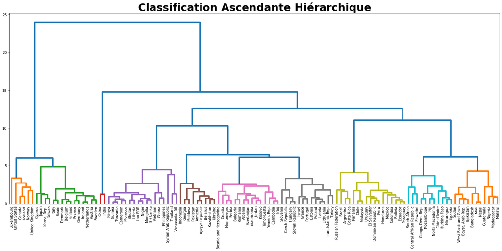

```python
plt.rcParams['lines.linewidth'] = 4
# Mise en forme du dendrogram
plt.figure(figsize=(25,10))
dendrogram(Z,
           labels = names,orientation = "top",
           leaf_font_size=10,
           color_threshold = 6,
           above_threshold_color='C10')
plt.title("Classification Ascendante Hiérarchique", fontsize = 30, fontweight = "bold")

plt.savefig(save + r"\02_dendrogram.png")
plt.show()
```

Nous avons ainsi les 10 clusters colorés en différentes couleurs. Maintenant, nous souhaitons faire une sélection de pays à l'intérieur de ces différents clusters. Dans un premier temps, nous importons les clusters dans notre dataset.

```python
# je rappatrie dans le df data mes clusters CAH
data = data.merge(classif,
                  how = "left",
                  left_on = "TableName",
                  right_on = "Zone"
                 ).drop("Zone", axis = 1)

data
```

|  | country | year_survey | quantile | nb_quantiles | income | gdpppp | 2008_pop | income_mean | gini | nb_gini_unique | Region | IncomeGroup | TableName | cluster_cah |
| --- | --- | --- | --- | --- | --- | --- | --- | --- | --- | --- | --- | --- | --- | --- |
| 0 | ALB | 2008 | 1 | 100 | 728.89795 | 7297.0 | 2947314.0 | 2994.829902 | 30.0 | 4 | Europe & Central Asia | Upper middle income | Albania | 6 |
| 1 | ALB | 2008 | 2 | 100 | 916.66235 | 7297.0 | 2947314.0 | 2994.829902 | 30.0 | 4 | Europe & Central Asia | Upper middle income | Albania | 6 |
| 2 | ALB | 2008 | 3 | 100 | 1010.91600 | 7297.0 | 2947314.0 | 2994.829902 | 30.0 | 4 | Europe & Central Asia | Upper middle income | Albania | 6 |
| 3 | ALB | 2008 | 4 | 100 | 1086.90780 | 7297.0 | 2947314.0 | 2994.829902 | 30.0 | 4 | Europe & Central Asia | Upper middle income | Albania | 6 |
| 4 | ALB | 2008 | 5 | 100 | 1132.69970 | 7297.0 | 2947314.0 | 2994.829902 | 30.0 | 4 | Europe & Central Asia | Upper middle income | Albania | 6 |
| ... | ... | ... | ... | ... | ... | ... | ... | ... | ... | ... | ... | ... | ... | ... |
| 11595 | ZAF | 2008 | 96 | 100 | 24553.56800 | 9602.0 | 49779472.0 | 5617.904880 | 63.0 | 6 | Sub-Saharan Africa | Upper middle income | South Africa | 9 |
| 11596 | ZAF | 2008 | 97 | 100 | 28858.03100 | 9602.0 | 49779472.0 | 5617.904880 | 63.0 | 6 | Sub-Saharan Africa | Upper middle income | South Africa | 9 |
| 11597 | ZAF | 2008 | 98 | 100 | 35750.29000 | 9602.0 | 49779472.0 | 5617.904880 | 63.0 | 6 | Sub-Saharan Africa | Upper middle income | South Africa | 9 |
| 11598 | ZAF | 2008 | 99 | 100 | 46297.31600 | 9602.0 | 49779472.0 | 5617.904880 | 63.0 | 6 | Sub-Saharan Africa | Upper middle income | South Africa | 9 |
| 11599 | ZAF | 2008 | 100 | 100 | 82408.55000 | 9602.0 | 49779472.0 | 5617.904880 | 63.0 | 6 | Sub-Saharan Africa | Upper middle income | South Africa | 9 |

11600 rows × 14 columns

Nous choisissons l'indice de Gini le plus élevé de chacun des clusters.Les distributions de revenus les plus inégalitaires pour chacun d'eux nous donneront matière à analyser des possibles tendances existantes en matières de revenus.

2.4.3 Sélection CAH

Retour au sommaire

```python
# je crée une liste de pays
liste_pays_cah = np.array([])

# je récupère un pays par Cluster
for k in np.sort(data.cluster_cah.unique()):
    liste_pays_cah = np.append(liste_pays_cah, np.array([data[data.cluster_cah == k].groupby("TableName").mean().reset_index().sort_values("gini", ascending = False).head(1).iloc[0,0]]))

print("Les pays de chaque cluster avec un indice de Gini le plus élevé sont :", liste_pays_cah)
```

```
Les pays de chaque cluster avec un indice de Gini le plus élevé sont : ['United States' 'Japan' 'China' 'Philippines' 'Georgia' 'Romania'
 'Iran, Islamic Rep.' 'Honduras' 'South Africa' 'Guatemala']
```

Nous affichons les distributions de revenus à l'échelle logarithmique dans le but d'afficher de possibles valeurs extrêmes dans le même graphique.

2.4.3 Graphique à ordonnée logarithmique

Retour au sommaire

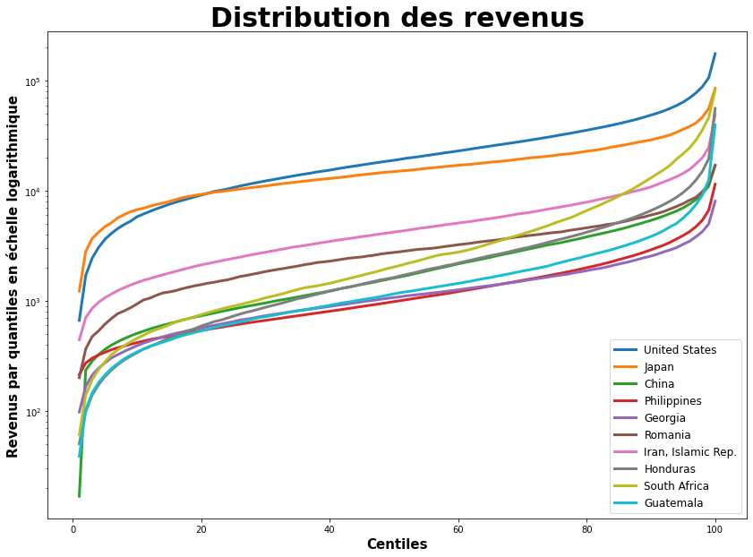

```python
plt.rcParams['lines.linewidth'] = 3

plt.figure(figsize = (14,10))

for k in liste_pays_cah:
        plt.plot(data[data.TableName == k]['quantile'], data[data.TableName == k].income,
             linewidth = 3,
             label = data[data.TableName == k].groupby('TableName').mean().reset_index().iloc[0,0])



plt.title("Distribution des revenus" , fontsize = 30, fontweight = "bold")
plt.xlabel("Centiles", fontsize = 15, fontweight = "bold")
plt.ylabel("Revenus par quantiles en échelle logarithmique", fontsize = 15, fontweight = "bold")
plt.yscale("log")
plt.legend(fontsize = 12)
plt.savefig(save + r"\01_plot_10cah.png")
plt.show()
```

2.4.4 Limites

Nous cherchons donc un autre moyen d'optimiser le nombre de clusters. Nous procédons par K-means. Il confirmera ou infirmera nos réserves ci-dessus.  
**2.5 Classification par K-means**  
2.5.1 Nombre de clusters optimal (entre 5 et 10)

Retour au sommaire

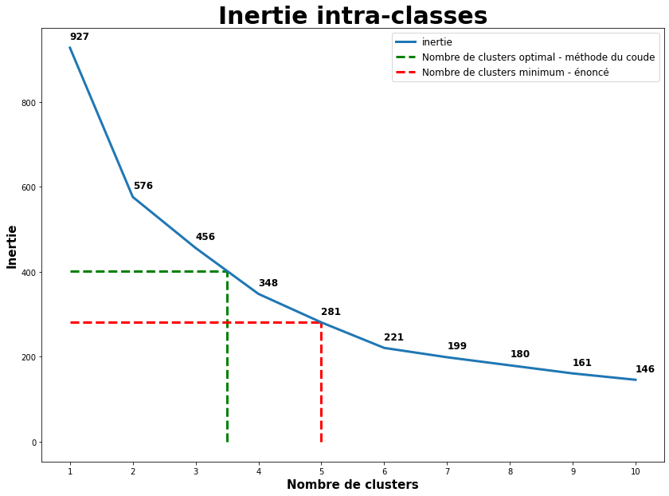

```python
#librairie pour évaluation des partitions
from sklearn import metrics, cluster

# je centre-réduit mes champs valeurs
X_scaled = preprocessing.StandardScaler().fit_transform(data.groupby('TableName').mean().reset_index().iloc[:,1:].values)

# Je calcule mes inerties
res = np.arange(10)
for k in np.arange(10):
    km = cluster.KMeans(n_clusters=k+1)
    km.fit(X_scaled)
    res[k] = km.inertia_

# allure des inerties
plt.figure(figsize = (14,10))
for k in np.arange(10):
    plt.text(k+1, res[k]+20, str(res[k]), fontsize = 12, fontweight = "bold")
plt.plot(np.arange(10)+1 ,res, label = "inertie")
plt.xticks(np.arange(10)+1)

# méthode du coude
plt.hlines((res[2] + res[3])/2, 1, 3.5, linestyles='--', color = 'g')
plt.vlines(3.5, 0, (res[2] + res[3])/2, linestyles='--', color = "g", label = "Nombre de clusters optimal - méthode du coude")

# méthode de l'énoncé
plt.hlines(res[4], 1, 5, linestyles='--', color = 'r')
plt.vlines(5, 0, res[4], linestyles='--', color = "r", label = "Nombre de clusters minimum - énoncé")


plt.legend(loc="upper right", fontsize = 12)
plt.xlabel('Nombre de clusters', fontweight='bold', fontsize = 15)
plt.ylabel('Inertie', fontweight='bold', fontsize = 15)
plt.title('Inertie intra-classes', fontweight = "bold", fontsize = 30)
plt.savefig(save + r"\02_km_inertie_intra_classe.png")
plt.show()
```

La méthode du coude me suggèrerait entre 3 et 4 clusters. Je choisis 5 clusters, comme proposé par l'énoncé (entre cinq et dix).  
Maintenant, nous réalisons le clustering par K-means à proprement parler, à 5 clusters. Nous suivons la même méthode que la Classification Ascendante Hiérarchique.  
2.5.2 Clasification K-means à 5 clusters

Retour au sommaire

```python
from sklearn.cluster import KMeans

# Nombre de clusters souhaités
n_clust = 5

# préparation des données pour le clustering
X = data.groupby('TableName').mean().reset_index().iloc[:,1:].values
names = data.groupby('TableName').mean().reset_index().TableName.values

# Centrage-réduction
X_scaled = preprocessing.StandardScaler().fit_transform(X)

# Clustering par K-means
km = KMeans(n_clusters = n_clust)
km.fit(X_scaled)

# Récupération des clusters attribués à chaque individu
clusters = pd.DataFrame({"Zone" : names,
                         "cluster_km" : km.labels_ })

clusters
```

|  | Zone | cluster_km |
| --- | --- | --- |
| 0 | Albania | 3 |
| 1 | Argentina | 2 |
| 2 | Armenia | 3 |
| 3 | Austria | 1 |
| 4 | Azerbaijan | 3 |
| ... | ... | ... |
| 111 | Uruguay | 2 |
| 112 | Venezuela, RB | 3 |
| 113 | Vietnam | 3 |
| 114 | West Bank and Gaza | 0 |
| 115 | Yemen, Rep. | 3 |

116 rows × 2 columns

```python
# je rapatrie dans mon df la classification K-means
data = data.merge(clusters,
                  how = "left",
                  left_on = "TableName",
                  right_on = "Zone").drop("Zone", axis = 1)

data
```

|  | country | year_survey | quantile | nb_quantiles | income | gdpppp | 2008_pop | income_mean | gini | nb_gini_unique | Region | IncomeGroup | TableName | cluster_cah | cluster_km |
| --- | --- | --- | --- | --- | --- | --- | --- | --- | --- | --- | --- | --- | --- | --- | --- |
| 0 | ALB | 2008 | 1 | 100 | 728.89795 | 7297.0 | 2947314.0 | 2994.829902 | 30.0 | 4 | Europe & Central Asia | Upper middle income | Albania | 6 | 3 |
| 1 | ALB | 2008 | 2 | 100 | 916.66235 | 7297.0 | 2947314.0 | 2994.829902 | 30.0 | 4 | Europe & Central Asia | Upper middle income | Albania | 6 | 3 |
| 2 | ALB | 2008 | 3 | 100 | 1010.91600 | 7297.0 | 2947314.0 | 2994.829902 | 30.0 | 4 | Europe & Central Asia | Upper middle income | Albania | 6 | 3 |
| 3 | ALB | 2008 | 4 | 100 | 1086.90780 | 7297.0 | 2947314.0 | 2994.829902 | 30.0 | 4 | Europe & Central Asia | Upper middle income | Albania | 6 | 3 |
| 4 | ALB | 2008 | 5 | 100 | 1132.69970 | 7297.0 | 2947314.0 | 2994.829902 | 30.0 | 4 | Europe & Central Asia | Upper middle income | Albania | 6 | 3 |
| ... | ... | ... | ... | ... | ... | ... | ... | ... | ... | ... | ... | ... | ... | ... | ... |
| 11595 | ZAF | 2008 | 96 | 100 | 24553.56800 | 9602.0 | 49779472.0 | 5617.904880 | 63.0 | 6 | Sub-Saharan Africa | Upper middle income | South Africa | 9 | 2 |
| 11596 | ZAF | 2008 | 97 | 100 | 28858.03100 | 9602.0 | 49779472.0 | 5617.904880 | 63.0 | 6 | Sub-Saharan Africa | Upper middle income | South Africa | 9 | 2 |
| 11597 | ZAF | 2008 | 98 | 100 | 35750.29000 | 9602.0 | 49779472.0 | 5617.904880 | 63.0 | 6 | Sub-Saharan Africa | Upper middle income | South Africa | 9 | 2 |
| 11598 | ZAF | 2008 | 99 | 100 | 46297.31600 | 9602.0 | 49779472.0 | 5617.904880 | 63.0 | 6 | Sub-Saharan Africa | Upper middle income | South Africa | 9 | 2 |
| 11599 | ZAF | 2008 | 100 | 100 | 82408.55000 | 9602.0 | 49779472.0 | 5617.904880 | 63.0 | 6 | Sub-Saharan Africa | Upper middle income | South Africa | 9 | 2 |

11600 rows × 15 columns

Dans notre dataset **data**, nous avons la possibilité de choisir, cluster par cluster :

- Les indices de Gini les plus élevés
- Les indices de Gini les plus faibles

Comme pour la Classification Ascendante Hiérarchique, les plus hauts Gini ne nous ont pas illustré de profil type satisfaisants.  
MNous sélectionnons donc cinq pays à hauts Gini et cinq pays à faible Gini. Parmi ces dix pays, nous choisirons cinq pays sur l'hypothèse que cinq profils différents seront visibles.

```python
# je crée une liste de pays
liste_pays_km_max = np.array([])
liste_pays_km_min = np.array([])

# je récupère un pays par Cluster
for k in np.sort(data.cluster_km.unique()):
    liste_pays_km_max = np.append(liste_pays_km_max, np.array([data[data.cluster_km == k].groupby("TableName").mean().reset_index().sort_values("gini", ascending = False).head(1).iloc[0,0]]))
    liste_pays_km_min = np.append(liste_pays_km_min, np.array([data[data.cluster_km == k].groupby("TableName").mean().reset_index().sort_values("gini", ascending = True).head(1).iloc[0,0]]))

print("Les pays à indices de Gini plus élevés, cluster par cluster, sont :", liste_pays_km_max)
print("Les pays à indices de Gini plus faibles, cluster par cluster, sont :", liste_pays_km_min)
```

```
Les pays à indices de Gini plus élevés, cluster par cluster, sont : ['Central African Republic' 'United States' 'South Africa' 'Philippines'
 'China']
Les pays à indices de Gini plus faibles, cluster par cluster, sont : ['Tajikistan' 'Slovenia' 'Indonesia' 'Slovak Republic' 'India']
```

J'illustre les dix distributions de ces deux groupes de pays dans deux graphiques logarithmiques.

2.5.3 Graphiques à ordonnée logarithmique : 5 Ginis Max, 5 Ginis Min

Retour au sommaire

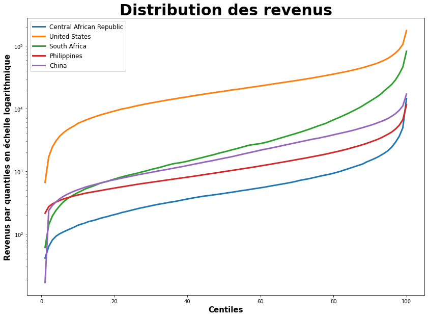

```python
plt.figure(figsize = (14,10))

for k in liste_pays_km_max:
    plt.plot(data[data.TableName == k]['quantile'], data[data.TableName == k].income,
             linewidth= 3,
             label = data[data.TableName == k].groupby('TableName').mean().reset_index().iloc[0,0])

plt.title("Distribution des revenus" , fontsize = 30, fontweight = "bold")
plt.xlabel("Centiles", fontsize = 15, fontweight = "bold")
plt.ylabel("Revenus par quantiles en échelle logarithmique", fontsize = 15, fontweight = "bold")
plt.yscale("log")
plt.legend(fontsize = 12)
plt.savefig(save + r"\02_plot_5km_max.png")
plt.show()
```

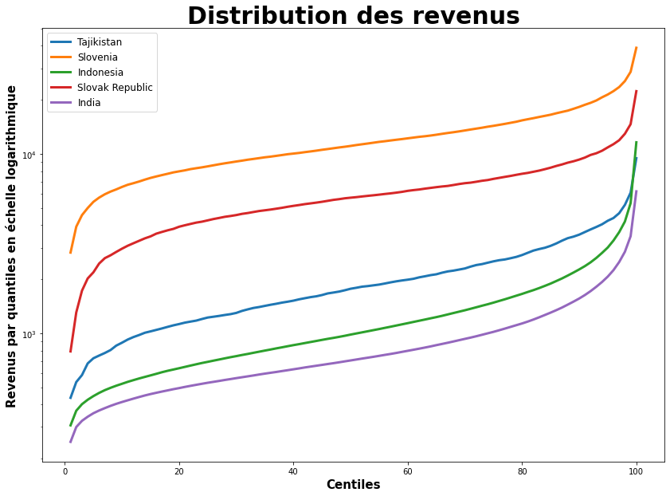

```python
plt.figure(figsize = (14,10))

for k in liste_pays_km_min:
    plt.plot(data[data.TableName == k]['quantile'], data[data.TableName == k].income,
             linewidth= 3,
             label = data[data.TableName == k].groupby('TableName').mean().reset_index().iloc[0,0])

plt.title("Distribution des revenus" , fontsize = 30, fontweight = "bold")
plt.xlabel("Centiles", fontsize = 15, fontweight = "bold")
plt.ylabel("Revenus par quantiles en échelle logarithmique", fontsize = 15, fontweight = "bold")
plt.yscale("log")
plt.legend(fontsize = 12)
plt.savefig(save + r"\02_plot_5km_min.png")
plt.show()
```

Au regard des différents graphiques, cinq types de profils semblent se dessiner avec des réalités géo-économiques différentes :

- **USA** : Gini élevé (distribution des revenus inégalitaire) & revenu moyen élevé (niveau de vie global élevé)
- **Afrique du Sud** : Gini élevé (distribution des revenus très inégalitaire) & revenu moyen moyen (niveau de vie disparate)
- **République Centre-africaine** : Gini élevé (distribution des revenus très inégalitaire) & revenu moyen faible (niveau de vie global faible)
- **Slovénie** : Gini faible (distribution des revenus relativement égalitaire) & revenu moyen élevé (niveau de vie global élevé)
- **Inde** : Gini faible (distribution des revenus relativement égalitaire) & revenu moyen faible (niveau de vie global faible)

Nous regroupons maintenant ces cinq profils dans un même graphique logarithmique.  
**2.6 Sélection finale**  
2.6.1 Graphique à ordonnée logarithmique

Retour au sommaire

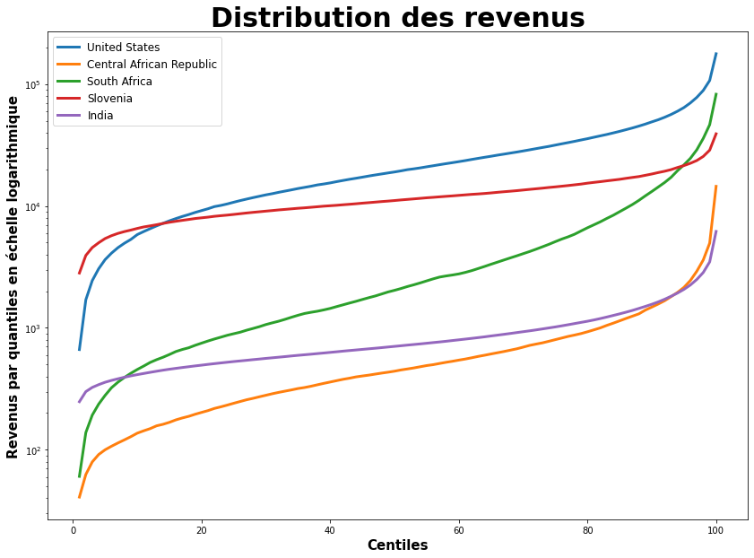

```python
liste_pays_km = ['United States', 'Central African Republic', 'South Africa', 'Slovenia', 'India']

plt.figure(figsize = (14,10))

for k in liste_pays_km:
    plt.plot(data[data.TableName == k]['quantile'], data[data.TableName == k].income,
             linewidth= 3,
             label = data[data.TableName == k].groupby('TableName').mean().reset_index().iloc[0,0])

plt.title("Distribution des revenus" , fontsize = 30, fontweight = "bold")
plt.xlabel("Centiles", fontsize = 15, fontweight = "bold")
plt.ylabel("Revenus par quantiles en échelle logarithmique", fontsize = 15, fontweight = "bold")
plt.yscale("log")
plt.legend(fontsize = 12)
plt.savefig(save + r"\02_plot_5km.png")
plt.show()
```

Retour au sommaire

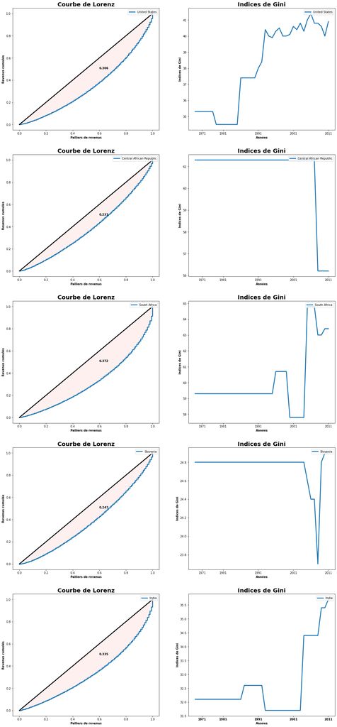

```python
fig, axes = plt.subplots(len(liste_pays_km), 2 ,sharex=False, figsize=(20, 45))

plt.xticks(fontweight = "bold")
for k in range(len(liste_pays_km)):

        # j'importe mes séries
        centiles = data[data.TableName == liste_pays_km_min[k]].income
        n = len(centiles)
        gini = data_gini[data_gini['Country Name'] == liste_pays_km[k]].iloc[:,4:].transpose()

        # je calcule mes ordonnées de Lorenz
        lorenz_centiles = np.cumsum(np.sort(centiles)) / centiles.sum()
        lorenz_centiles = np.append([0],lorenz_centiles) # La courbe de Lorenz commence à 0
        xaxis = np.linspace(0,1,len(lorenz_centiles))

        # je calcule mon gini
        gini_centile = 2*(0.5 - ( (lorenz_centiles.sum() - lorenz_centiles[-1]/2 - lorenz_centiles[0]/2) /n ) )

        # je fixe mes deux plots, mon aire colorée et ma légende
        axes[k, 0].plot(xaxis,lorenz_centiles, drawstyle='steps-post', label = liste_pays_km[k])
        axes[k, 0].plot([0,1], [0,1], color='black')
        axes[k, 0].fill_between(xaxis, lorenz_centiles, xaxis, color='#fff0f0')
        axes[k, 0].legend(loc="upper right")

        axes[k, 1].plot(gini.index, gini, label = liste_pays_km[k])
        axes[k, 1].legend(loc="upper right")

        # set-up des plots
        axes[k, 0].set_xlabel('Palliers de revenus', fontweight='bold')
        axes[k, 0].set_ylabel('Revenus cumulés', fontweight='bold')
        axes[k, 0].set_title('Courbe de Lorenz', fontweight = "bold", fontsize = 20)
        axes[k, 0].text(0.6, 0.5, "{:,.3f}".format(gini_centile), fontsize = 10, fontweight = "bold")
        axes[k, 1].set_xlabel('Années', fontweight='bold')
        axes[k, 1].set_ylabel('Indices de Gini', fontweight='bold')
        axes[k, 1].set_title('Indices de Gini', fontweight = "bold", fontsize = 20)
        axes[k, 1].xaxis.set_ticks(['1971','1981', '1991', '2001', '2011' ])

plt.savefig(save + r"\02_km_subplots_lorenz_gini.png")
plt.show()
```

Maintenant, nous classons tous nos pays pour connaître :

- l'indice de Gini moyen mondial
- le top 5 des plus faibles indices de Gini (les cinq pays les plus égalitaires dans leurs distributions de revenus)
- le top 5 des plus forts indices de Gini (les cinq pays les plus inégalitaires dans leurs distributions de revenus)
- le classement de la France

**2.7 Classements globaux des indices de Gini**  
2.7.1 Moyenne pondérée par population

Retour au sommaire

```python
print("La moyenne des indices de Gini de mon échantillon, pondérés par les populations est de :",
      "{:,.2f}".format(sum([x*y/data.groupby("country").mean()["2008_pop"].sum() for (x,y) in zip(data.groupby("country").mean()['2008_pop'], data.groupby("country").mean().gini)]))
     )
```

[output not shown]

2.7.2 Les 5 Ginis les plus faibles

```python
data.groupby("TableName").mean().sort_values("gini").head(5).reset_index()[["TableName", "gini"]]
```

|  | TableName | gini |
| --- | --- | --- |
| 0 | Slovenia | 23.7 |
| 1 | Denmark | 25.2 |
| 2 | Slovak Republic | 26.0 |
| 3 | Czech Republic | 26.3 |
| 4 | Ukraine | 26.6 |

2.7.3 Les 5 Ginis les plus élevés

```python
data.groupby("TableName").mean().sort_values("gini", ascending = False).head(5).reset_index()[["TableName", "gini"]]
```

|  | TableName | gini |
| --- | --- | --- |
| 0 | South Africa | 63.0 |
| 1 | Central African Republic | 56.2 |
| 2 | Honduras | 55.5 |
| 3 | Colombia | 55.3 |
| 4 | Guatemala | 54.6 |

2.7.4 Classement de la France

```python
classement = data.groupby('TableName').mean().sort_values("gini").reset_index()

classement[classement.TableName == "France"][["TableName", "gini"]]
```

|  | TableName | gini |
| --- | --- | --- |
| 40 | France | 33.0 |

La France a donc le 41ème gini le plus faible de notre échantillon. Sa distribution de salaires est donc plus tassée que la moyenne mondiale.

Conformément au projet, nous allons maintenant mettre en oeuvre un algorithme de simulation de classes de revenus parents et enfants, applicable à notre échantillon actuel.  
**Mission 03 : Classifications des revenus**

**Consignes brèves**  
A date, seulement deux des trois variables explicatives souhaitées sont à notre disposition :

- le revenu moyen du pays (**income_mean**)
- indice de Gini du pays (**gini**)

Nous cherchons maintenant à calculer, pour un individu , la classe de revenu de ses parents.

**Méthode**  
Elle sera détailliée pour chaque sous-partie de la mission 03.  
**3.1 Génération des $ln(Y_{parents})$**

Retour au sommaire

```python
# choix arbitraire de la moyenne à 10 et std à 3
ln_y_parent = np.random.normal(10, 3, 1000000)
```

```python
import math
# je stocke ln_y_parents dans un df
simul = pd.DataFrame(ln_y_parent,
                     columns = ["ln_y_parent"])

# je calcule mes y_parents
simul['y_parent'] = simul["ln_y_parent"].apply(math.exp)
```

**3.2 Génération des $\epsilon$**

**Consignes brèves**  
Générez $n$ réalisations du terme d'erreur $\epsilon$ selon une loi normale de moyenne 0 et d'écart type 1.

Retour au sommaire

```python
# Je génère mes epsilon dans une liste
epsilon = np.random.randn(1000000)

# je stocke ma liste dans mon df
simul["epsilon"] = epsilon

simul
```

|  | ln_y_parent | y_parent | epsilon |
| --- | --- | --- | --- |
| 0 | 8.920281 | 7.482195e+03 | -1.132497 |
| 1 | 14.422386 | 1.834690e+06 | 1.433918 |
| 2 | 2.302167 | 9.995817e+00 | -1.848761 |
| 3 | 5.443844 | 2.313298e+02 | -0.406534 |
| 4 | 8.912016 | 7.420605e+03 | -0.627475 |
| ... | ... | ... | ... |
| 999995 | 12.983958 | 4.353727e+05 | -0.028576 |
| 999996 | 3.440706 | 3.120899e+01 | 0.504369 |
| 999997 | 12.791459 | 3.591369e+05 | -0.873124 |
| 999998 | 13.724164 | 9.127014e+05 | 0.127190 |
| 999999 | 10.107455 | 2.452516e+04 | 0.270299 |

1000000 rows × 3 columns

**3.3 Calcul de l'estimateur $y_{child}$ avec p = 0.9**

Pour une valeur donnée de $\rho_j$ (par exemple 0.9), calculez $y_{child} = e^{\alpha+\rho_jln(y_{parent})+\epsilon}$.

Le choix de $\alpha$ n'a aucune incidence sur le résultat final.  
À ce stade, $y_{child}$ contient des valeurs dont l'ordre de grandeur ne reflète pas la réalité, mais cela n'a pas d'influence pour la suite.

Retour au sommaire

```python
# avec un pj = 0.9, alpha = 0

import math
alpha = 0
pj = 0.9

# je calcule mes y_child dans une liste
y_child = [math.exp(alpha + pj * x + y) for x,y in zip(ln_y_parent, epsilon)]

# je stocke cette liste dans mon df
simul["y_child_09"] =  y_child
del y_child

# J'ai mon df pré-calcul des centiles
simul
```

|  | ln_y_parent | y_parent | epsilon | y_child_09 |
| --- | --- | --- | --- | --- |
| 0 | 8.920281 | 7.482195e+03 | -1.132497 | 9.880730e+02 |
| 1 | 14.422386 | 1.834690e+06 | 1.433918 | 1.819487e+06 |
| 2 | 2.302167 | 9.995817e+00 | -1.848761 | 1.250057e+00 |
| 3 | 5.443844 | 2.313298e+02 | -0.406534 | 8.938255e+01 |
| 4 | 8.912016 | 7.420605e+03 | -0.627475 | 1.625124e+03 |
| ... | ... | ... | ... | ... |
| 999995 | 12.983958 | 4.353727e+05 | -0.028576 | 1.154954e+05 |
| 999996 | 3.440706 | 3.120899e+01 | 0.504369 | 3.663503e+01 |
| 999997 | 12.791459 | 3.591369e+05 | -0.873124 | 4.173890e+04 |
| 999998 | 13.724164 | 9.127014e+05 | 0.127190 | 2.627445e+05 |
| 999999 | 10.107455 | 2.452516e+04 | 0.270299 | 1.169608e+04 |

1000000 rows × 4 columns

Nous calculons maintenant les centiles des revenus enfants et parents.  
Pour faciliter la lecture dees tableaux, nous choisissons 10 quantiles (déciles). Nous poursuivons les simulations sur 1 million de revenus probables.

**3.4 Calcul des $c_{i,child}$ et $c_{i,parent}$**

Pour chacun des $n$ individus générés, calculez la classe de revenu $c_{i,child}$ ainsi que la classe de revenu de ses parents $c_{i,parent}$ , à partir de $y_{child}$ et de $y_{parent}$.

Retour au sommaire

```python
nb_quantiles = 10
size = 1000000

# j'associe à chaque y_child et y_parent leur centile dans un dictionnaire
# cette astuce n'est faisable que grâce à l'unicité des ln_y_parents générés aléatoirement ainsi que des epsilons
dico_child_09 = {a:int(b) for a,b in zip(np.sort(simul['y_child_09']), np.round(np.arange(1, nb_quantiles+1, nb_quantiles/size)-0.5+1/size) )}
dico_parent = {a:int(b) for a,b in zip(np.sort(simul.y_parent), np.round(np.arange(1, nb_quantiles+1, nb_quantiles/size)-0.5+1/size) )}

# J'applique maintenant mes dicos à mes colonnes dans mon df simul
simul["ci_child_09"] = simul["y_child_09"].map(dico_child_09)
simul["ci_parent"] = simul["y_parent"].map(dico_parent)

# je libère de la mémoire, mes équivalences sont dans mon df simul maintenant
del dico_child_09
del dico_parent

# aspect de mes distributions de centiles
simul
```

|  | ln_y_parent | y_parent | epsilon | y_child_09 | ci_child_09 | ci_parent |
| --- | --- | --- | --- | --- | --- | --- |
| 0 | 8.920281 | 7.482195e+03 | -1.132497 | 9.880730e+02 | 3 | 4 |
| 1 | 14.422386 | 1.834690e+06 | 1.433918 | 1.819487e+06 | 10 | 10 |
| 2 | 2.302167 | 9.995817e+00 | -1.848761 | 1.250057e+00 | 1 | 1 |
| 3 | 5.443844 | 2.313298e+02 | -0.406534 | 8.938255e+01 | 1 | 1 |
| 4 | 8.912016 | 7.420605e+03 | -0.627475 | 1.625124e+03 | 3 | 4 |
| ... | ... | ... | ... | ... | ... | ... |
| 999995 | 12.983958 | 4.353727e+05 | -0.028576 | 1.154954e+05 | 9 | 9 |
| 999996 | 3.440706 | 3.120899e+01 | 0.504369 | 3.663503e+01 | 1 | 1 |
| 999997 | 12.791459 | 3.591369e+05 | -0.873124 | 4.173890e+04 | 8 | 9 |
| 999998 | 13.724164 | 9.127014e+05 | 0.127190 | 2.627445e+05 | 9 | 9 |
| 999999 | 10.107455 | 2.452516e+04 | 0.270299 | 1.169608e+04 | 6 | 6 |

1000000 rows × 6 columns

Nous avons donc associé, à chaque revenu enfant $y_{child}$ et à chaque revenu parent $y_{parent}$ les déciles associés. Calculons maintenant les fréquences conditionnelles des parents par enfants.  
Pour chaque décile enfant, quelle est la distribution des classes parents ?

Nous calculons donc des probabilités conditionnelles. Pour chaque classe enfant, quelle est la répartition en % des classes parents ?

**La méthode**

- isoler classe enfant par classe enfant
- pour chacune d'elle obtenir les classes parents
- calculer, toujours dans cette classe enfant, la proportion de chaque classe parent (10 classes parents)

Nous obtenons les répartitions conditionnelles.  
**3.5 Calcul des probabilités conditionnelles**

3.5.1 Calcul des probabilités conditionnelles parents

Retour au sommaire

```python
# je calcule mes probas en divisant deux groupby
proba_cond_parent_09 = simul.groupby(["ci_child_09", "ci_parent"]).count()/simul.groupby(["ci_child_09", "ci_parent"]).count().groupby(level = 0).sum()

# je supprime les colonnes étrangères à mes probas
proba_cond_parent_09 = proba_cond_parent_09.reset_index().drop(["ln_y_parent", "epsilon", "y_child_09"], axis = 1)

# je renomme ma colonne selon ce qu'elle contient
proba_cond_parent_09.rename(columns = {"y_parent" : "proba_cond_parent_09"}, inplace = True)

# Je rajoute dans mon df toutes les probabilités conditionnelles absentes.
# Si elle n'existent pas, je rajoute une ligne avec la classe enfant, la classe parent et une probabilité de zéro.
for i in np.sort(simul['ci_child_09'].unique()):
    for j in np.sort(simul.ci_parent.unique()):
        coucou = proba_cond_parent_09[(proba_cond_parent_09['ci_child_09'] == i) & (proba_cond_parent_09.ci_parent == j)]
        if len(coucou) <= 0:
            proba_cond_parent_09 = proba_cond_parent_09.append(pd.DataFrame([i, j, 0],
                                                        index = ["ci_child_09", "ci_parent", "proba_cond_parent_09"]).transpose(),
                                           )

# aspect de mon tableau de proba conditionnelles
proba_cond_parent_09 = proba_cond_parent_09.sort_values(["ci_child_09", "ci_parent"]).reset_index(drop = True)
proba_cond_parent_09
```

|  | ci_child_09 | ci_parent | proba_cond_parent_09 |
| --- | --- | --- | --- |
| 0 | 1 | 1 | 0.75508 |
| 1 | 1 | 2 | 0.20540 |
| 2 | 1 | 3 | 0.03449 |
| 3 | 1 | 4 | 0.00449 |
| 4 | 1 | 5 | 0.00053 |
| ... | ... | ... | ... |
| 95 | 10 | 6 | 0.00052 |
| 96 | 10 | 7 | 0.00462 |
| 97 | 10 | 8 | 0.03577 |
| 98 | 10 | 9 | 0.20527 |
| 99 | 10 | 10 | 0.75378 |

100 rows × 3 columns

Illustrons les probabilités conditionnelles dans un tableau à double entrées **tab_double**.  
L'index représente les classes enfants, les colonnes les classes parents.

```python
tab_double = pd.pivot_table(proba_cond_parent_09,
               index = "ci_child_09",
               columns = "ci_parent",
               aggfunc = sum).reset_index(drop = True)
tab_double.columns = [x for x in proba_cond_parent_09.ci_parent.unique()]
tab_double
```

|  | 1 | 2 | 3 | 4 | 5 | 6 | 7 | 8 | 9 | 10 |
| --- | --- | --- | --- | --- | --- | --- | --- | --- | --- | --- |
| 0 | 0.75508 | 0.20540 | 0.03449 | 0.00449 | 0.00053 | 0.00000 | 0.00001 | 0.00000 | 0.00000 | 0.00000 |
| 1 | 0.20413 | 0.44071 | 0.24873 | 0.08250 | 0.02018 | 0.00341 | 0.00032 | 0.00002 | 0.00000 | 0.00000 |
| 2 | 0.03567 | 0.24693 | 0.33882 | 0.23554 | 0.10605 | 0.03067 | 0.00581 | 0.00048 | 0.00003 | 0.00000 |
| 3 | 0.00462 | 0.08338 | 0.23455 | 0.29628 | 0.22529 | 0.11330 | 0.03586 | 0.00621 | 0.00051 | 0.00000 |
| 4 | 0.00045 | 0.02002 | 0.10558 | 0.22724 | 0.27814 | 0.22124 | 0.11213 | 0.03178 | 0.00337 | 0.00005 |
| 5 | 0.00005 | 0.00320 | 0.03111 | 0.11251 | 0.22187 | 0.27982 | 0.22567 | 0.10529 | 0.01996 | 0.00052 |
| 6 | 0.00000 | 0.00035 | 0.00629 | 0.03539 | 0.11294 | 0.22733 | 0.29479 | 0.23455 | 0.08374 | 0.00462 |
| 7 | 0.00000 | 0.00001 | 0.00043 | 0.00563 | 0.03160 | 0.10345 | 0.23651 | 0.33914 | 0.24725 | 0.03598 |
| 8 | 0.00000 | 0.00000 | 0.00000 | 0.00042 | 0.00336 | 0.02026 | 0.08428 | 0.24676 | 0.43987 | 0.20505 |
| 9 | 0.00000 | 0.00000 | 0.00000 | 0.00000 | 0.00004 | 0.00052 | 0.00462 | 0.03577 | 0.20527 | 0.75378 |

```python
print("\nP(c_i_parent = {} | c_i_child = {}, pj = {}) = {}".format(2, 4, 0.9, "{:,.3%}".format(tab_double.loc[4, 2])))
```

```
P(c_i_parent = 2 | c_i_child = 4, pj = 0.9) = 2.002%
```

Calculons maintenant la répartition des classes enfants conditionnellement à leur classe parent.  
**La méthode** (analogue à la méthode plus haut) :

- isoler classe parent par classe parent
- pour chacune d'elle obtenir les classes enfants
- calculer, toujours dans cette classe parent, la proportion de chaque classe enfant présente (10 classes enfant)

3.5.2 Calcul des probabilités conditionnelles enfants

Retour au sommaire

```python
# je calcule mes probas en divisant deux groupby
proba_cond_child_09 = simul.groupby(["ci_parent", "ci_child_09"]).count()/simul.groupby(["ci_parent", "ci_child_09"]).count().groupby(level = 0).sum()

# je supprime les colonnes étrangères à mes probas
proba_cond_child_09 = proba_cond_child_09.reset_index().drop(["ln_y_parent", "epsilon", "y_child_09"], axis = 1)

# je renomme ma colonne selon ce qu'elle contient
proba_cond_child_09.rename(columns = {"y_parent" : "proba_cond_child_09"}, inplace = True)

# Je rajoute dans mon df toutes les probabilités conditionnelles absentes.
# Si elle n'existent pas, je rajoute une ligne avec la classe enfant, la classe parent et une probabilité de zéro.
for i in np.sort(simul['ci_child_09'].unique()):
    for j in np.sort(simul.ci_parent.unique()):
        coucou = proba_cond_child_09[(proba_cond_child_09['ci_child_09'] == i) & (proba_cond_child_09.ci_parent == j)]
        if len(coucou) <= 0:
            proba_cond_child_09 = proba_cond_child_09.append(pd.DataFrame([i, j, 0],
                                                        index = ["ci_child_09", "ci_parent", "proba_cond_child_09"]).transpose(),
                                           )

# je libère de l'espace
del coucou

# aspect de mon tableau de proba conditionnelles
proba_cond_child_09 = proba_cond_child_09.sort_values(["ci_child_09", "ci_parent"]).reset_index(drop = True)
proba_cond_child_09
```

|  | ci_parent | ci_child_09 | proba_cond_child_09 |
| --- | --- | --- | --- |
| 0 | 1 | 1 | 0.75508 |
| 1 | 2 | 1 | 0.20540 |
| 2 | 3 | 1 | 0.03449 |
| 3 | 4 | 1 | 0.00449 |
| 4 | 5 | 1 | 0.00053 |
| ... | ... | ... | ... |
| 95 | 6 | 10 | 0.00052 |
| 96 | 7 | 10 | 0.00462 |
| 97 | 8 | 10 | 0.03577 |
| 98 | 9 | 10 | 0.20527 |
| 99 | 10 | 10 | 0.75378 |

100 rows × 3 columns

Le constat est sans appel : la similarité entre **proba_cond_child_09** et **proba_cond_parent_09** est réelle.  
Ainsi, illustrer la répartition conditionnelle des classes parents en fonction des classes enfants est équivalent à illustrer la répartition conditionnelle des classes enfants en fonction des classes parents.

Nous souhaitons maintenant illustrer les répartitions des quantiles enfants conditionnellement aux classes parents.  
3.5.3 Graphique des distributions conditionnelles ($p_j$ = 0.9)

Retour au sommaire

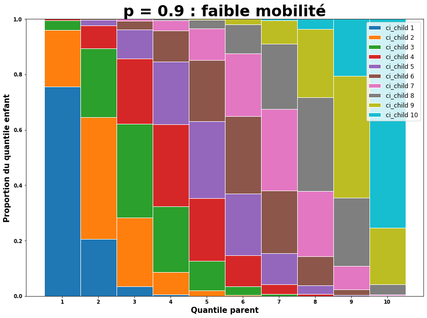

```python
# Names of group and bar width
barWidth = 10
x = np.sort(simul.ci_parent.unique())
bars = np.zeros(len(x))

plt.figure(figsize=(14,10))

for k in proba_cond_child_09.ci_child_09.unique():
    y = proba_cond_child_09[proba_cond_child_09.ci_child_09 == k].sort_values("ci_parent").proba_cond_child_09.tolist()
    plt.bar(x,
            y,
            bottom = bars,
            edgecolor = 'white',
            width = 1,
            label = "ci_child " + str(k))

    bars = np.add(bars, y).tolist()


    # Custom X axis
plt.xlabel("Quantile parent", fontweight = "bold", fontsize = 15)
plt.ylabel("Proportion du quantile enfant", fontweight = "bold", fontsize = 15)
plt.title("p = 0.9 : faible mobilité", fontweight = "bold", fontsize = 30)
plt.xticks(x,fontweight = "bold", fontsize = 10)
plt.yticks(fontweight = "bold", fontsize = 10)
plt.legend(fontsize = 12)

plt.savefig(save + r"\03_pj_09.png")
# Show graphic
plt.show()
```

Avec un grand pj (0.9 ici) la probabilité qu'un enfant soit de même classe de revenu que ses parents est élevée. Nous comprenons la relation dans l'équation suivante : $y_{child} = e^{\alpha+\rho_jln(y_{parent})+\epsilon}$

Maintenant, nous souhaitons comprendre l'influence du coefficient d'élasticité sur nos répartitions conditionnelles. Précédemment, il était de 0.9. Fixons-le à 0.05 et voyons l'influence sur les répartitions conditionnelles.

3.5.3 Graphique des distributions conditionnelles ($p_j$ = 0.05)

Retour au sommaire

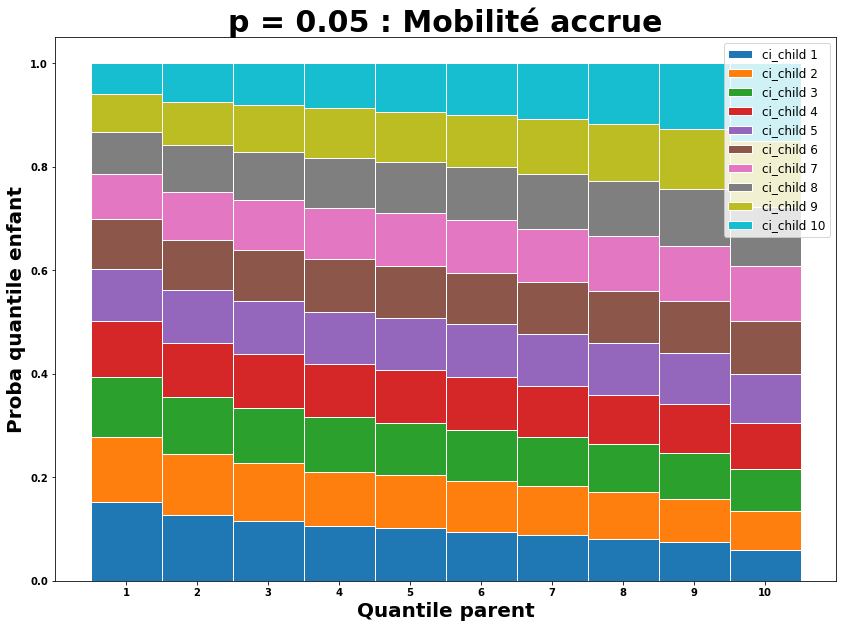

```python
alpha = 0
pj = 0.05

# je recalcule mes y_child avec pj = 0.05
y_child = [math.exp(alpha + pj * x + y) for x,y in zip(ln_y_parent, epsilon)]
simul["y_child_005"] =  y_child
del y_child

# je refais un dico pour les y_child générés avec pj = 0.05
dico_child_005 = {a:int(b) for a,b in zip(np.sort(simul.y_child_005), np.round(np.arange(1, nb_quantiles+1, nb_quantiles/size)-0.5+1/size) )}

# j'impute dans le df simul mes classes enfants avec pj = 0.05
simul["ci_child_005"] = simul["y_child_005"].map(dico_child_005)

# je libère de l'espace
del dico_child_005

# nous avons expliqué plus haut que les distributions conditionnelles des parents selon la classe enfant
# sont équivalentes aux distributions conditionnelles des enfants selon la classe parents
proba_cond_parent_005 = simul.groupby(["ci_child_005", "ci_parent"]).count()/simul.groupby(["ci_child_005", "ci_parent"]).count().groupby(level = 0).sum()
proba_cond_parent_005 = proba_cond_parent_005.reset_index().drop(["ln_y_parent", "epsilon", "y_child_005"], axis = 1)
proba_cond_parent_005.rename(columns = {"y_parent" : "proba_cond_parent_005"}, inplace = True)

for i in np.sort(simul.ci_child_005.unique()):
    for j in np.sort(simul.ci_parent.unique()):
        coucou = proba_cond_parent_005[(proba_cond_parent_005.ci_child_005 == i) & (proba_cond_parent_005.ci_parent == j)]
        if len(coucou) <= 0:
            proba_cond_parent_005 = proba_cond_parent_005.append(pd.DataFrame([i, j, 0],
                                                        index = ["ci_child_005", "c_100_parent", "proba_cond_parent_005"]).transpose(),
                                           )

# je libère de la mémoire
del coucou

# je ré-arrange mon df
proba_cond_parent_005 = proba_cond_parent_005.sort_values(["ci_child_005", "ci_parent"]).reset_index(drop = True)
proba_cond_parent_005

# je crée mon graphique
barWidth = 10
bars = np.zeros(len(x))

plt.figure(figsize=(14,10))

for k in proba_cond_parent_005.ci_child_005.unique():
    y = proba_cond_parent_005[proba_cond_parent_005.ci_child_005 == k].sort_values("ci_parent").proba_cond_parent_005.tolist()
    plt.bar(x,
            y,
            bottom = bars,
            edgecolor = 'white',
            width = 1,
            label = "ci_child "+ str(k))

    bars = np.add(bars, y).tolist()


# Custom X axis
plt.xlabel("Quantile parent", fontweight = "bold", fontsize = 20)
plt.ylabel("Proba quantile enfant", fontweight = "bold", fontsize = 20)
plt.title("p = 0.05 : Mobilité accrue", fontweight = "bold", fontsize = 30)
plt.xticks(x,fontweight = "bold", fontsize = 10)
plt.yticks(fontweight = "bold", fontsize = 10)
plt.legend(fontsize = 12)
plt.savefig(save + r"\03_pj_005.png")

# je libère de l'espace
del x, y, bars

# Show graphic
plt.show()
```

Il est manifeste qu'avec un pj bien inférieur, la probabilité qu'un enfant soit de même classe de revenu que ses parents est moins élevée.

Il pourrait être intéressant de comprendre la nature de la corrélation entre la variation du pj et la variation de la probabilité de la classe enfant conditionnelle à la classe parent.  
Cette corrélation est positive : plus le coefficient augmente, plus la probabilité de la classe enfant d'être conforme à la classe parent augmente. Augmente-t-elle de la même manière en fonction du décile ? Nous n'étudierons pas la question dans ce projet, mais elle mérite d'être soulevé.

Appliquons maintenant toute cette méthode à notre dataset global.  
3.5.4 Clarification du dataset et effacement des classes intermédiaires

Retour au sommaire

```python
proba_cond_parent_09
```

|  | ci_child_09 | ci_parent | proba_cond_parent_09 |
| --- | --- | --- | --- |
| 0 | 1 | 1 | 0.75508 |
| 1 | 1 | 2 | 0.20540 |
| 2 | 1 | 3 | 0.03449 |
| 3 | 1 | 4 | 0.00449 |
| 4 | 1 | 5 | 0.00053 |
| ... | ... | ... | ... |
| 95 | 10 | 6 | 0.00052 |
| 96 | 10 | 7 | 0.00462 |
| 97 | 10 | 8 | 0.03577 |
| 98 | 10 | 9 | 0.20527 |
| 99 | 10 | 10 | 0.75378 |

100 rows × 3 columns

**3.6 Réplication des 500 clones**

Retour au sommaire

```python
%%time
data_new = pd.concat([data] * 500)
```

```
Wall time: 633 ms
```

Après avoir répliqué notre dataset 500 fois, nous obtenons un dataset **data_new** de 5 800 000 lignes avec 116 pays. Chacun d'entre eux contient 50 000 lignes. Chacun de leurs centiles contient 500 personnes à revenus égaux. Nous considérons, à partir de maintenant que les **income** sont nos $y_{child}$. Nous pouvons d'ores et déjà leur associer leurs centiles situés dans la colonne **quantile**. Notre objectif est donc de calculer, pour chaque pays, selon son coefficient d'élasticité :

- $y_{parents}$
- les $c_{i,parents}$ associés

**Méthode** :

- Associer à chaque pays un pj spécifique récupéré sur le site de la WDI
- Créer une fonction qui à une distribution de $y_{child}$ donnée, à pj donné, calcule une table de $y_{parents}$ associés et donc de $c_{i,parents}$ associés.  
  **3.7 Calcul des $c_{i,parent}$ finaux**  
  3.7.1 Téléchargement et imputation des coefficients d'élasticité de la WDI

Disponibles sur [cette page](https://www.worldbank.org/en/topic/poverty/brief/what-is-the-global-database-on-intergenerational-mobility-gdim). Nous les stockons dans le dataset **coef_pj**.

Retour au sommaire

```python
# données relatives aux coefficients d'élasticité de 2018
data_wid = pd.read_csv(source + r"\GDIMMay2018.csv", sep = ",")

# les coef d'élasticité se trouvent dans la colonne IGEincome, la seule que je conserve dans ma table
# je prends les moyennes de tous mes coefficients existants
coef_pj = data_wid[data_wid.IGEincome.isna() == False].groupby('wbcode').mean()[["IGEincome"]]
coef_pj.reset_index(inplace = True)


# je renomme mes colonnes pour un merge plus efficace
coef_pj.columns = ["country", "p_j"]

# allure de mes coefs
coef_pj
```

|  | country | p_j |
| --- | --- | --- |
| 0 | ALB | 0.815874 |
| 1 | AUS | 0.275000 |
| 2 | AUT | 0.245267 |
| 3 | BEL | 0.183176 |
| 4 | BEN | 0.855116 |
| ... | ... | ... |
| 70 | USA | 0.537666 |
| 71 | UZB | 0.496764 |
| 72 | VNM | 0.480000 |
| 73 | ZAF | 0.677000 |
| 74 | ZAR | 0.707703 |

75 rows × 2 columns

Nous les intégrons à notre dataset **data_new**.

```python
# j'inclus mes coefficients pj dans ma table globale
data_new = data_new.merge(coef_pj,
                          how = "left",
                          on = "country")

data_new
```

|  | country | year_survey | quantile | nb_quantiles | income | gdpppp | 2008_pop | income_mean | gini | nb_gini_unique | Region | IncomeGroup | TableName | cluster_cah | cluster_km | p_j |
| --- | --- | --- | --- | --- | --- | --- | --- | --- | --- | --- | --- | --- | --- | --- | --- | --- |
| 0 | ALB | 2008 | 1 | 100 | 728.89795 | 7297.0 | 2947314.0 | 2994.829902 | 30.0 | 4 | Europe & Central Asia | Upper middle income | Albania | 6 | 3 | 0.815874 |
| 1 | ALB | 2008 | 2 | 100 | 916.66235 | 7297.0 | 2947314.0 | 2994.829902 | 30.0 | 4 | Europe & Central Asia | Upper middle income | Albania | 6 | 3 | 0.815874 |
| 2 | ALB | 2008 | 3 | 100 | 1010.91600 | 7297.0 | 2947314.0 | 2994.829902 | 30.0 | 4 | Europe & Central Asia | Upper middle income | Albania | 6 | 3 | 0.815874 |
| 3 | ALB | 2008 | 4 | 100 | 1086.90780 | 7297.0 | 2947314.0 | 2994.829902 | 30.0 | 4 | Europe & Central Asia | Upper middle income | Albania | 6 | 3 | 0.815874 |
| 4 | ALB | 2008 | 5 | 100 | 1132.69970 | 7297.0 | 2947314.0 | 2994.829902 | 30.0 | 4 | Europe & Central Asia | Upper middle income | Albania | 6 | 3 | 0.815874 |
| ... | ... | ... | ... | ... | ... | ... | ... | ... | ... | ... | ... | ... | ... | ... | ... | ... |
| 5799995 | ZAF | 2008 | 96 | 100 | 24553.56800 | 9602.0 | 49779472.0 | 5617.904880 | 63.0 | 6 | Sub-Saharan Africa | Upper middle income | South Africa | 9 | 2 | 0.677000 |
| 5799996 | ZAF | 2008 | 97 | 100 | 28858.03100 | 9602.0 | 49779472.0 | 5617.904880 | 63.0 | 6 | Sub-Saharan Africa | Upper middle income | South Africa | 9 | 2 | 0.677000 |
| 5799997 | ZAF | 2008 | 98 | 100 | 35750.29000 | 9602.0 | 49779472.0 | 5617.904880 | 63.0 | 6 | Sub-Saharan Africa | Upper middle income | South Africa | 9 | 2 | 0.677000 |
| 5799998 | ZAF | 2008 | 99 | 100 | 46297.31600 | 9602.0 | 49779472.0 | 5617.904880 | 63.0 | 6 | Sub-Saharan Africa | Upper middle income | South Africa | 9 | 2 | 0.677000 |
| 5799999 | ZAF | 2008 | 100 | 100 | 82408.55000 | 9602.0 | 49779472.0 | 5617.904880 | 63.0 | 6 | Sub-Saharan Africa | Upper middle income | South Africa | 9 | 2 | 0.677000 |

5800000 rows × 16 columns

Vérification des $p_j$ manquants (**NaN**).

```python
data_new[data_new.p_j.isna()]
```

|  | country | year_survey | quantile | nb_quantiles | income | gdpppp | 2008_pop | income_mean | gini | nb_gini_unique | Region | IncomeGroup | TableName | cluster_cah | cluster_km | p_j |
| --- | --- | --- | --- | --- | --- | --- | --- | --- | --- | --- | --- | --- | --- | --- | --- | --- |
| 100 | ARG | 2008 | 1 | 100 | 254.08942 | 13220.0 | 40080160.0 | 5847.884654 | 44.9 | 23 | Latin America & Caribbean | Upper middle income | Argentina | 8 | 2 | NaN |
| 101 | ARG | 2008 | 2 | 100 | 470.50150 | 13220.0 | 40080160.0 | 5847.884654 | 44.9 | 23 | Latin America & Caribbean | Upper middle income | Argentina | 8 | 2 | NaN |
| 102 | ARG | 2008 | 3 | 100 | 623.45420 | 13220.0 | 40080160.0 | 5847.884654 | 44.9 | 23 | Latin America & Caribbean | Upper middle income | Argentina | 8 | 2 | NaN |
| 103 | ARG | 2008 | 4 | 100 | 734.97455 | 13220.0 | 40080160.0 | 5847.884654 | 44.9 | 23 | Latin America & Caribbean | Upper middle income | Argentina | 8 | 2 | NaN |
| 104 | ARG | 2008 | 5 | 100 | 832.31850 | 13220.0 | 40080160.0 | 5847.884654 | 44.9 | 23 | Latin America & Caribbean | Upper middle income | Argentina | 8 | 2 | NaN |
| ... | ... | ... | ... | ... | ... | ... | ... | ... | ... | ... | ... | ... | ... | ... | ... | ... |
| 5799895 | YEM | 2008 | 96 | 100 | 2568.65110 | 2224.0 | 21892146.0 | 1042.635870 | 34.7 | 2 | Middle East & North Africa | Low income | Yemen, Rep. | 6 | 3 | NaN |
| 5799896 | YEM | 2008 | 97 | 100 | 2893.90400 | 2224.0 | 21892146.0 | 1042.635870 | 34.7 | 2 | Middle East & North Africa | Low income | Yemen, Rep. | 6 | 3 | NaN |
| 5799897 | YEM | 2008 | 98 | 100 | 3307.27220 | 2224.0 | 21892146.0 | 1042.635870 | 34.7 | 2 | Middle East & North Africa | Low income | Yemen, Rep. | 6 | 3 | NaN |
| 5799898 | YEM | 2008 | 99 | 100 | 4137.02640 | 2224.0 | 21892146.0 | 1042.635870 | 34.7 | 2 | Middle East & North Africa | Low income | Yemen, Rep. | 6 | 3 | NaN |
| 5799899 | YEM | 2008 | 100 | 100 | 9050.43750 | 2224.0 | 21892146.0 | 1042.635870 | 34.7 | 2 | Middle East & North Africa | Low income | Yemen, Rep. | 6 | 3 | NaN |

2650000 rows × 16 columns

```python
data_new[data_new.p_j.isna()].TableName.unique()
```

```
array(['Argentina', 'Armenia', 'Azerbaijan', 'Burkina Faso', 'Bulgaria',
       'Bhutan', 'Central African Republic', "Côte d'Ivoire", 'Cameroon',
       'Congo, Dem. Rep.', 'Costa Rica', 'Dominican Republic', 'Estonia',
       'Fiji', 'Georgia', 'Honduras', 'Hungary', 'Indonesia',
       'Iran, Islamic Rep.', 'Iraq', 'Iceland', 'Israel', 'Cambodia',
       'Lao PDR', 'Liberia', 'Sri Lanka', 'Lithuania', 'Moldova',
       'Mexico', 'Montenegro', 'Mozambique', 'Mauritania', 'Niger',
       'Nicaragua', 'Philippines', 'Poland', 'Paraguay',
       'West Bank and Gaza', 'Romania', 'Sudan', 'El Salvador', 'Serbia',
       'Eswatini', 'Syrian Arab Republic', 'Thailand', 'Tajikistan',
       'Timor-Leste', 'Turkey', 'Ukraine', 'Uruguay', 'Venezuela, RB',
       'Kosovo', 'Yemen, Rep.'], dtype=object)
```

Pour chacun de ces pays, les coefficients de mobilité sont absents. Nous remercions OpenClassrooms de nous avoir fourni des $p_j$. Nous aurions pû, en leur absence, calculer la moyenne des $p_j$ régionaux disponibles dans notre dataset et les réimputer là où ils sont manquants.

3.7.2 Téléchargement des $p_j$ manquants

| Region | Base Case | Optimistic (high mobility) | Pessimistic (low mobility) |
| --- | --- | --- | --- |
| Nordic European countries & Canada | 0.2 | 0.15 | 0.3 |
| Europe (except nordic countries) | 0.4 | 0.3 | 0.5 |
| Australia/New Zealand/USA | 0.4 | 0.3 | 0.5 |
| Asia | 0.5 | 0.4 | 0.6 |
| Latin America/Africa | 0.66 | 0.5 | 0.9 |

Nous privilégions les $p_j$ *base case* que nous stockons dans un dictionnaire **dico_pj**, dans lequel nous associons les valeurs suivantes :

- 'Europe & Central Asia': 0.4
- 'Latin America & Caribbean': 0.66
- 'Sub-Saharan Africa' : 0.66
- 'South Asia' : 0.5
- 'North America' : 0.3 (il y a le Canada et les USA : 0.3 de moyenne)
- 'East Asia & Pacific' : 0.5
- 'Middle East & North Africa' : 0.66

Nous appliquons ensuite ce dictionnaire auxrégions des pays dont le $p_j$ est manquant. Notre imputation sera finalisée.

3.7.3 Dictionnaire zone:$p_j$

Retour au sommaire

```python
# dico_pj associant à une zone un pj
dico_pj = dict(zip(data.Region.unique(), [0.4, 0.66, 0.66, 0.5, 0.3, 0.5, 0.66]))

# je remplace tous les p_j en NaN par le pj de sa zone géographique
data_new.loc[data_new[data_new.p_j.isna()].index,"p_j"] = data_new.loc[data_new[data_new.p_j.isna()].index, "Region"].map(dico_pj)

# je supprime mon dico_pj
del dico_pj
```

Nous calculons à présent les $c_{i,parents}$ dans **data_new**.  
3.7.4 Calcul des $c_{i,parents}$ finaux

**Méthode** : créer une fonction **c_i_parents** réalisant les tâches suivantes :

- tri du dataset **data_new** en fonction du pays et de ses quantiles pour une meilleure visibilité
- calcul des y_parents
- calcul des centiles $c_{i,parents}$ associés aux $y_{parent}$
- stockage des $c_{i,parents}$ et associations aux $c_{i,child}$

  Retour au sommaire

```python
# je réordonne mon df selon les pays et les quantiles associés
data_new = data_new.sort_values(["country", "quantile"]).reset_index(drop = True)

data_new
```

|  | country | year_survey | quantile | nb_quantiles | income | gdpppp | 2008_pop | income_mean | gini | nb_gini_unique | Region | IncomeGroup | TableName | cluster_cah | cluster_km | p_j |
| --- | --- | --- | --- | --- | --- | --- | --- | --- | --- | --- | --- | --- | --- | --- | --- | --- |
| 0 | ALB | 2008 | 1 | 100 | 728.89795 | 7297.0 | 2947314.0 | 2994.829902 | 30.0 | 4 | Europe & Central Asia | Upper middle income | Albania | 6 | 3 | 0.815874 |
| 1 | ALB | 2008 | 1 | 100 | 728.89795 | 7297.0 | 2947314.0 | 2994.829902 | 30.0 | 4 | Europe & Central Asia | Upper middle income | Albania | 6 | 3 | 0.815874 |
| 2 | ALB | 2008 | 1 | 100 | 728.89795 | 7297.0 | 2947314.0 | 2994.829902 | 30.0 | 4 | Europe & Central Asia | Upper middle income | Albania | 6 | 3 | 0.815874 |
| 3 | ALB | 2008 | 1 | 100 | 728.89795 | 7297.0 | 2947314.0 | 2994.829902 | 30.0 | 4 | Europe & Central Asia | Upper middle income | Albania | 6 | 3 | 0.815874 |
| 4 | ALB | 2008 | 1 | 100 | 728.89795 | 7297.0 | 2947314.0 | 2994.829902 | 30.0 | 4 | Europe & Central Asia | Upper middle income | Albania | 6 | 3 | 0.815874 |
| ... | ... | ... | ... | ... | ... | ... | ... | ... | ... | ... | ... | ... | ... | ... | ... | ... |
| 5799995 | ZAF | 2008 | 100 | 100 | 82408.55000 | 9602.0 | 49779472.0 | 5617.904880 | 63.0 | 6 | Sub-Saharan Africa | Upper middle income | South Africa | 9 | 2 | 0.677000 |
| 5799996 | ZAF | 2008 | 100 | 100 | 82408.55000 | 9602.0 | 49779472.0 | 5617.904880 | 63.0 | 6 | Sub-Saharan Africa | Upper middle income | South Africa | 9 | 2 | 0.677000 |
| 5799997 | ZAF | 2008 | 100 | 100 | 82408.55000 | 9602.0 | 49779472.0 | 5617.904880 | 63.0 | 6 | Sub-Saharan Africa | Upper middle income | South Africa | 9 | 2 | 0.677000 |
| 5799998 | ZAF | 2008 | 100 | 100 | 82408.55000 | 9602.0 | 49779472.0 | 5617.904880 | 63.0 | 6 | Sub-Saharan Africa | Upper middle income | South Africa | 9 | 2 | 0.677000 |
| 5799999 | ZAF | 2008 | 100 | 100 | 82408.55000 | 9602.0 | 49779472.0 | 5617.904880 | 63.0 | 6 | Sub-Saharan Africa | Upper middle income | South Africa | 9 | 2 | 0.677000 |

5800000 rows × 16 columns

**Rappel** : la colonne **income** représente les $y_{child}$. Nous calculons les $y_{parent}$ avec la formule suivante :  
$y_{child} = e^{\alpha+\rho_jln(y_{parent})+\epsilon}$ $\implies \ \ y_{parents} = e^{(\frac{ln(y_{child}) -\ \alpha -\ \epsilon}{p_j})} $ .

(d'où l'importance des $p_j$). Ci-dessous la fonction **c_i_parents**

```python
import math

def c_i_parents(y_child, pj, alpha=0, nb_quantiles=100):

    # taille de l'échantillon
    size = y_child.shape[0]

    # je stocke mes y_child dans un df
    simul = pd.DataFrame(y_child).rename(columns = {"income" : "y_child"})

    # Je calcule mes epsilon
    epsilon = np.random.randn(len(y_child))

    # je calcule mes y_parents
    y_parents = [math.exp((math.log(x) - alpha - y)/pj) for x,y in zip(y_child,epsilon)]

    # j'associe en dico mes ci_parents
    dico_parents = {a:int(b) for a,b in zip(np.sort(y_parents), np.round(np.arange(1, nb_quantiles+1, nb_quantiles/size)-0.5+1/size))}

    # je retourne en liste mes ci_parents
    return [dico_parents[x] for x in y_parents]
```

```python
# je refais un dico avec les pj
dico_pj = {x:y for x,y in zip(data_new[["country", "p_j"]].drop_duplicates().country,
                              data_new[["country", "p_j"]].drop_duplicates().p_j)}
```

Nous stockons dans la liste **centile_parents** la concaténation verticale des $c{i,parent}$ que calcule ma fonction **c_i_parents** sur la base de chaque pays et de ses revenus enfants ordonnés, de son pj associé, avec un $\alpha$ à 2 fixé arbitrairement.

```python
%%time
centile_parents = np.array([], dtype = int)
for k in data_new.country.unique():
    centile_parents = np.append(centile_parents,
                                c_i_parents(data_new[data_new.country == k].income, dico_pj[k], alpha = 2),
                                axis = 0
                               )
centile_parents
```

```
Wall time: 41 s
```

```
array([ 1, 76,  3, ..., 98, 98, 87])
```

Le time de 41s pour les 116 pays est satisfaisant. Nous ajoutons maintenant cette liste dans la colonne **ci_parents** du dataset **data_new**.

```python
data_new["ci_parents"] = centile_parents
del centile_parents
data_new
```

|  | country | year_survey | quantile | nb_quantiles | income | gdpppp | 2008_pop | income_mean | gini | nb_gini_unique | Region | IncomeGroup | TableName | cluster_cah | cluster_km | p_j | ci_parents |
| --- | --- | --- | --- | --- | --- | --- | --- | --- | --- | --- | --- | --- | --- | --- | --- | --- | --- |
| 0 | ALB | 2008 | 1 | 100 | 728.89795 | 7297.0 | 2947314.0 | 2994.829902 | 30.0 | 4 | Europe & Central Asia | Upper middle income | Albania | 6 | 3 | 0.815874 | 1 |
| 1 | ALB | 2008 | 1 | 100 | 728.89795 | 7297.0 | 2947314.0 | 2994.829902 | 30.0 | 4 | Europe & Central Asia | Upper middle income | Albania | 6 | 3 | 0.815874 | 76 |
| 2 | ALB | 2008 | 1 | 100 | 728.89795 | 7297.0 | 2947314.0 | 2994.829902 | 30.0 | 4 | Europe & Central Asia | Upper middle income | Albania | 6 | 3 | 0.815874 | 3 |
| 3 | ALB | 2008 | 1 | 100 | 728.89795 | 7297.0 | 2947314.0 | 2994.829902 | 30.0 | 4 | Europe & Central Asia | Upper middle income | Albania | 6 | 3 | 0.815874 | 2 |
| 4 | ALB | 2008 | 1 | 100 | 728.89795 | 7297.0 | 2947314.0 | 2994.829902 | 30.0 | 4 | Europe & Central Asia | Upper middle income | Albania | 6 | 3 | 0.815874 | 13 |
| ... | ... | ... | ... | ... | ... | ... | ... | ... | ... | ... | ... | ... | ... | ... | ... | ... | ... |
| 5799995 | ZAF | 2008 | 100 | 100 | 82408.55000 | 9602.0 | 49779472.0 | 5617.904880 | 63.0 | 6 | Sub-Saharan Africa | Upper middle income | South Africa | 9 | 2 | 0.677000 | 98 |
| 5799996 | ZAF | 2008 | 100 | 100 | 82408.55000 | 9602.0 | 49779472.0 | 5617.904880 | 63.0 | 6 | Sub-Saharan Africa | Upper middle income | South Africa | 9 | 2 | 0.677000 | 98 |
| 5799997 | ZAF | 2008 | 100 | 100 | 82408.55000 | 9602.0 | 49779472.0 | 5617.904880 | 63.0 | 6 | Sub-Saharan Africa | Upper middle income | South Africa | 9 | 2 | 0.677000 | 98 |
| 5799998 | ZAF | 2008 | 100 | 100 | 82408.55000 | 9602.0 | 49779472.0 | 5617.904880 | 63.0 | 6 | Sub-Saharan Africa | Upper middle income | South Africa | 9 | 2 | 0.677000 | 98 |
| 5799999 | ZAF | 2008 | 100 | 100 | 82408.55000 | 9602.0 | 49779472.0 | 5617.904880 | 63.0 | 6 | Sub-Saharan Africa | Upper middle income | South Africa | 9 | 2 | 0.677000 | 87 |

5800000 rows × 17 columns

Nous avons recalculé, en fonction du coefficient de mobilité (élasticité) de chaque pays, les classifications parents probables en fonction des income des $y_{child}$.

3.7.5 Transition  
Ainsi, pour chaque pays et chaque individu nous avons dans notre dataset :

- $m_j$ : data_new.income_mean
- $G_j$ : data_new.gini
- $c_{i,parents}$ : data_new.ci_parents

À présent, nous souhaitons comprendre :

- La significativité de la différence des **income** entre les différents pays
- Quelles sont les variables explicatives des **income** parmi
  - income_mean
  - indice de gini
  - classification parents

**Mission 04 : Tests statistiques**

Pour comprendre ces relations, nous réalisons plusieurs tests :

- ANOVA : expliquer la significativité des différences des **income** entre les différents pays
- Regression linéaire 1 : expliquer l'income avec l'income moyen et le gini
- Régression linéaire 2 : expliquer l'income avec l'income moyen, le gini et la classification parents

**Etape intermédiaire**

- Nous transformons les colonnes numériques en integers
- Nous échantillonnons nos bases avec un nombre de lignes réduit pour en tirer des conclusions statistiques sur notre population globale.

  Retour au sommaire

```python
data_new.ci_parents = pd.to_numeric(data_new.ci_parents)
data_new["ln_income"] = data_new["income"].apply(math.log)
data_new["ln_income_mean"] = data_new["income_mean"].apply(math.log)
data_new["ln_gdpppp"] = data_new["gdpppp"].apply(math.log)
data_new["ln_gini"] = data_new["gini"].apply(math.log)
data_new["ln_p_j"] = data_new["p_j"].apply(math.log)
data_new["ln_ci_parents"] = data_new["ci_parents"].apply(math.log)
```

Nous choisissons une taille d'échantillon nous permettant de faire des tests avec suffisamment de lignes.  
Notre dataset fait 5.8 millions de lignes. Nous en choisis 1% : 58 000. Cela semble suffisant pour réaliser des teststype ANOVA et régressions linéaires. Le choix des lignes est fait aléatoirement avec **[train_test_split](https://scikit-learn.org/stable/modules/generated/sklearn.model_selection.train_test_split.html)** de *scikit-learn*.

```python
from sklearn.model_selection import train_test_split

# je choisis 99% pour la size test et 1% pour la size train sur laquelle je vais faire mes modèles
data_train, data_test = train_test_split(data_new, test_size= 0.99)

# allure de mon échantillon test
data_train
```

|  | country | year_survey | quantile | nb_quantiles | income | gdpppp | 2008_pop | income_mean | gini | nb_gini_unique | Region | IncomeGroup | TableName | cluster_cah | cluster_km | p_j | ci_parents | ln_income | ln_income_mean | ln_gdpppp | ln_gini | ln_p_j | ln_ci_parents |
| --- | --- | --- | --- | --- | --- | --- | --- | --- | --- | --- | --- | --- | --- | --- | --- | --- | --- | --- | --- | --- | --- | --- | --- |
| 4811976 | SVK | 2008 | 24 | 100 | 4185.60800 | 20515.0000 | 5379233.0 | 6096.579894 | 26.0 | 8 | Europe & Central Asia | High income | Slovak Republic | 7 | 3 | 0.596078 | 35 | 8.339407 | 8.715483 | 9.928912 | 3.258097 | -0.517383 | 3.555348 |
| 5501029 | USA | 2008 | 3 | 100 | 2439.73540 | 43261.0000 | 304093966.0 | 25503.581661 | 40.8 | 16 | North America | High income | United States | 1 | 1 | 0.537666 | 5 | 7.799645 | 10.146574 | 10.675007 | 3.708682 | -0.620518 | 1.609438 |
| 1420628 | ECU | 2008 | 42 | 100 | 1739.48280 | 7560.0000 | 14535739.0 | 3383.741001 | 49.8 | 11 | Latin America & Caribbean | Upper middle income | Ecuador | 8 | 2 | 1.029957 | 48 | 7.461343 | 8.126737 | 8.930626 | 3.908015 | 0.029517 | 3.871201 |
| 5328433 | TZA | 2007 | 57 | 100 | 499.86500 | 1201.0000 | 41853944.0 | 588.766986 | 40.3 | 4 | Sub-Saharan Africa | Lower middle income | Tanzania | 4 | 3 | 0.511973 | 33 | 6.214338 | 6.378030 | 7.090910 | 3.696351 | -0.669484 | 3.496508 |
| 5024247 | SYR | 2004 | 49 | 100 | 514.16675 | 4512.0000 | 20664038.0 | 685.817495 | 37.5 | 2 | Middle East & North Africa | Low income | Syrian Arab Republic | 4 | 3 | 0.660000 | 22 | 6.242548 | 6.530612 | 8.414496 | 3.624341 | -0.415515 | 3.091042 |
| ... | ... | ... | ... | ... | ... | ... | ... | ... | ... | ... | ... | ... | ... | ... | ... | ... | ... | ... | ... | ... | ... | ... | ... |
| 5768786 | ZAF | 2008 | 38 | 100 | 1368.08520 | 9602.0000 | 49779472.0 | 5617.904880 | 63.0 | 6 | Sub-Saharan Africa | Upper middle income | South Africa | 9 | 2 | 0.677000 | 57 | 7.221167 | 8.633714 | 9.169727 | 4.143135 | -0.390084 | 4.043051 |
| 2767006 | KEN | 2007 | 35 | 100 | 366.75800 | 1429.0000 | 39791981.0 | 519.320032 | 46.5 | 4 | Sub-Saharan Africa | Lower middle income | Kenya | 4 | 3 | 0.670373 | 74 | 5.904702 | 6.252520 | 7.264730 | 3.839452 | -0.399921 | 4.304065 |
| 4619934 | RUS | 2008 | 40 | 100 | 4265.85060 | 14766.0000 | 142742366.0 | 7156.770709 | 41.6 | 17 | Europe & Central Asia | Upper middle income | Russian Federation | 8 | 2 | 0.330000 | 27 | 8.358397 | 8.875814 | 9.600083 | 3.728100 | -1.108663 | 3.295837 |
| 3492950 | MKD | 2008 | 86 | 100 | 7594.56450 | 8809.0000 | 2067313.0 | 4599.396322 | 42.8 | 3 | Europe & Central Asia | Upper middle income | North Macedonia | 9 | 0 | 0.416638 | 89 | 8.935188 | 8.433680 | 9.083529 | 3.756538 | -0.875538 | 4.488636 |
| 3729021 | MRT | 2008 | 59 | 100 | 1553.30710 | 2226.7344 | 3296238.0 | 1798.609083 | 35.7 | 6 | Sub-Saharan Africa | Lower middle income | Mauritania | 6 | 3 | 0.660000 | 17 | 7.348142 | 7.494769 | 7.708291 | 3.575151 | -0.415515 | 2.833213 |

58000 rows × 23 columns

Retour au sommaire

**4.1 ANOVA**

Afin de tester l'égalité de mes revenus selon les pays avec un ANOVA à un facteur, nous vérifions les hypothèses suivantes du modèle :

- normalité des income (variable endogène)
- normalité des résidus
- homoscédasticité des résidus
- indépendance des sous-échantillons entre eux

Commençons par un test de normalité simple :  
**Kolmogorov-Smirnov sur la normalité des incomes de l'échantillon**  
Rappel du test : $\begin{cases} H_0 : F_{train} = F_{normal} \\ H_1 : F_{train} \neq F_{normal} \end{cases}$

Retour au sommaire

```python
st.ks_2samp(data_train.income, np.random.normal(data_train.income.mean(), data_train.income.std(ddof = 0), len(data_train)))
```

```
KstestResult(statistic=0.25905172413793104, pvalue=0.0)
```

Avec une p-value égale à zéro nous rejettons l'hypothèse de normalité de l'échantillon $H_0$.  
Pour autant, compte-tenu de sa taille (58 000 lignes), par la loi faible des grands nombres, ma série converge en probabilité vers une loi normale. Nous pouvons donc procéder au test ANOVA.

Nous cherchons à répondre à la question suivante :  
**Les revenus moyens des pays sont-ils égaux entre eux ?**  
Les graphiques plus hauts nous amènent à penser que les niveaux de revenus sont différents. Voyons si l'**ANOVA** confirme cette tendance.

**4.1.1 ANOVA des income non-log**  
4.1.1.1 Vue des pays et significativité

Retour au sommaire

```python
import statsmodels.formula.api as smf
anova_pays = smf.ols('income~TableName', data=data_train).fit()
print(anova_pays.summary())
```

```
                            OLS Regression Results
==============================================================================
Dep. Variable:                 income   R-squared:                       0.492
Model:                            OLS   Adj. R-squared:                  0.491
Method:                 Least Squares   F-statistic:                     487.1
Date:                Wed, 21 Jul 2021   Prob (F-statistic):               0.00
Time:                        19:46:19   Log-Likelihood:            -5.9379e+05
No. Observations:               58000   AIC:                         1.188e+06
Df Residuals:                   57884   BIC:                         1.189e+06
Df Model:                         115
Covariance Type:            nonrobust
=========================================================================================================
                                            coef    std err          t      P>|t|      [0.025      0.975]
---------------------------------------------------------------------------------------------------------
Intercept                              3006.9460    307.923      9.765      0.000    2403.415    3610.477
TableName[T.Argentina]                 2864.0660    434.131      6.597      0.000    2013.166    3714.966
TableName[T.Armenia]                  -1408.5604    433.473     -3.249      0.001   -2258.170    -558.951
TableName[T.Austria]                   1.378e+04    426.671     32.308      0.000    1.29e+04    1.46e+04
TableName[T.Azerbaijan]                -756.9344    426.283     -1.776      0.076   -1592.451      78.582
TableName[T.Bangladesh]               -2005.3422    427.258     -4.694      0.000   -2842.770   -1167.914
TableName[T.Belarus]                    849.3625    428.050      1.984      0.047      10.382    1688.343
TableName[T.Belgium]                   1.226e+04    434.352     28.235      0.000    1.14e+04    1.31e+04
TableName[T.Bhutan]                   -1575.4654    430.492     -3.660      0.000   -2419.232    -731.698
TableName[T.Bolivia]                     72.0287    421.641      0.171      0.864    -754.390     898.448
TableName[T.Bosnia and Herzegovina]    3332.3611    433.038      7.695      0.000    2483.604    4181.118
TableName[T.Brazil]                    2162.7713    427.653      5.057      0.000    1324.570    3000.973
TableName[T.Bulgaria]                  1906.9388    424.381      4.493      0.000    1075.151    2738.727
TableName[T.Burkina Faso]             -2144.8984    448.412     -4.783      0.000   -3023.788   -1266.009
TableName[T.Cambodia]                 -1565.9035    433.911     -3.609      0.000   -2416.372    -715.435
TableName[T.Cameroon]                 -1032.2892    437.532     -2.359      0.018   -1889.853    -174.725
TableName[T.Canada]                    2.055e+04    434.797     47.266      0.000    1.97e+04    2.14e+04
TableName[T.Central African Republic] -2195.6983    432.392     -5.078      0.000   -3043.188   -1348.208
TableName[T.Chile]                     3895.4579    427.851      9.105      0.000    3056.868    4734.048
TableName[T.China]                     -369.6753    430.492     -0.859      0.390   -1213.442     474.092
TableName[T.Colombia]                   311.3165    435.695      0.715      0.475    -542.648    1165.281
TableName[T.Congo, Dem. Rep.]         -2745.7048    423.453     -6.484      0.000   -3575.674   -1915.736
TableName[T.Costa Rica]                2253.5523    437.067      5.156      0.000    1396.898    3110.207
TableName[T.Croatia]                   4853.6189    431.540     11.247      0.000    4007.798    5699.440
TableName[T.Cyprus]                    1.425e+04    427.062     33.374      0.000    1.34e+04    1.51e+04
TableName[T.Czech Republic]            5229.6121    432.392     12.095      0.000    4382.122    6077.102
```

[output cut: 84 more lines]

```
TableName[T.United States]             2.306e+04    430.285     53.596      0.000    2.22e+04    2.39e+04
TableName[T.Uruguay]                   2344.6447    424.194      5.527      0.000    1513.223    3176.067
TableName[T.Venezuela, RB]               65.6535    426.866      0.154      0.878    -771.006     902.313
TableName[T.Vietnam]                  -1597.3096    436.149     -3.662      0.000   -2452.164    -742.455
TableName[T.West Bank and Gaza]       -1841.8667    431.964     -4.264      0.000   -2688.519    -995.214
TableName[T.Yemen, Rep.]              -1947.4997    423.637     -4.597      0.000   -2777.830   -1117.169
==============================================================================
Omnibus:                    73286.596   Durbin-Watson:                   2.008
Prob(Omnibus):                  0.000   Jarque-Bera (JB):         21525154.714
Skew:                           6.774   Prob(JB):                         0.00
Kurtosis:                      96.399   Cond. No.                         119.
==============================================================================

Notes:
[1] Standard Errors assume that the covariance matrix of the errors is correctly specified.
```

Nous résumons l'information ci-dessous :  
4.1.1.2 Vue globale du test

```python
import statsmodels.api as sm

anova_1 = sm.stats.anova_lm(anova_pays, typ=2)
anova_1["eta_square"] = ["{:,.2%}".format(anova_1.sum_sq[0]/anova_1.sum_sq.sum()), "NaN"]
anova_1
```

|  | sum_sq | df | F | PR(>F) | eta_square |
| --- | --- | --- | --- | --- | --- |
| TableName | 2.565572e+12 | 115.0 | 487.140414 | 0.0 | 49.18% |
| Residual | 2.650884e+12 | 57884.0 | NaN | NaN | NaN |

À présent, nous retirons de notre test ces pays non-significatifs pour observer une amélioration probable du modèle.  
4.1.1.3 Suppression des pays non-significatifs

```python
backwardation = ["Azerbaijan", "Bolivia", "China", "Colombia", "Dominican Republic", "Ecuador", "El Salvador","Guatemala", "Honduras","Jordan","Kazakhstan","Kosovo",
                 "Moldova", "Mongolia","Morocco","Nicaragua","Paraguay","Peru", "Romania","Tajikistan","Thailand", "Ukraine","Venezuela, RB"]
print(smf.ols('income~TableName', data=data_train[data_train.TableName.isin(backwardation) == False]).fit().summary())
```

```
                            OLS Regression Results
==============================================================================
Dep. Variable:                 income   R-squared:                       0.490
Model:                            OLS   Adj. R-squared:                  0.489
Method:                 Least Squares   F-statistic:                     483.7
Date:                Wed, 21 Jul 2021   Prob (F-statistic):               0.00
Time:                        19:46:19   Log-Likelihood:            -4.7918e+05
No. Observations:               46424   AIC:                         9.585e+05
Df Residuals:                   46331   BIC:                         9.594e+05
Df Model:                          92
Covariance Type:            nonrobust
=========================================================================================================
                                            coef    std err          t      P>|t|      [0.025      0.975]
---------------------------------------------------------------------------------------------------------
Intercept                              3006.9460    334.923      8.978      0.000    2350.491    3663.401
TableName[T.Argentina]                 2864.0660    472.198      6.065      0.000    1938.551    3789.581
TableName[T.Armenia]                  -1408.5604    471.482     -2.988      0.003   -2332.672    -484.449
TableName[T.Austria]                   1.378e+04    464.083     29.703      0.000    1.29e+04    1.47e+04
TableName[T.Bangladesh]               -2005.3422    464.722     -4.315      0.000   -2916.204   -1094.480
TableName[T.Belarus]                    849.3625    465.583      1.824      0.068     -63.188    1761.913
TableName[T.Belgium]                   1.226e+04    472.438     25.959      0.000    1.13e+04    1.32e+04
TableName[T.Bhutan]                   -1575.4654    468.240     -3.365      0.001   -2493.222    -657.709
TableName[T.Bosnia and Herzegovina]    3332.3611    471.009      7.075      0.000    2409.177    4255.546
TableName[T.Brazil]                    2162.7713    465.151      4.650      0.000    1251.068    3074.475
TableName[T.Bulgaria]                  1906.9388    461.592      4.131      0.000    1002.212    2811.666
TableName[T.Burkina Faso]             -2144.8984    487.730     -4.398      0.000   -3100.857   -1188.940
TableName[T.Cambodia]                 -1565.9035    471.958     -3.318      0.001   -2490.949    -640.858
TableName[T.Cameroon]                 -1032.2892    475.896     -2.169      0.030   -1965.053     -99.526
TableName[T.Canada]                    2.055e+04    472.921     43.455      0.000    1.96e+04    2.15e+04
TableName[T.Central African Republic] -2195.6983    470.306     -4.669      0.000   -3117.504   -1273.892
TableName[T.Chile]                     3895.4579    465.367      8.371      0.000    2983.332    4807.584
TableName[T.Congo, Dem. Rep.]         -2745.7048    460.583     -5.961      0.000   -3648.454   -1842.956
TableName[T.Costa Rica]                2253.5523    475.391      4.740      0.000    1321.778    3185.326
TableName[T.Croatia]                   4853.6189    469.379     10.341      0.000    3933.628    5773.609
TableName[T.Cyprus]                    1.425e+04    464.508     30.683      0.000    1.33e+04    1.52e+04
TableName[T.Czech Republic]            5229.6121    470.306     11.120      0.000    4307.806    6151.418
TableName[T.Côte d'Ivoire]            -2635.1952    469.841     -5.609      0.000   -3556.090   -1714.300
TableName[T.Denmark]                   1.396e+04    480.073     29.083      0.000     1.3e+04    1.49e+04
TableName[T.Egypt, Arab Rep.]         -1127.6625    466.237     -2.419      0.016   -2041.495    -213.831
TableName[T.Estonia]                   4720.4252    464.936     10.153      0.000    3809.143    5631.707
```

[output cut: 61 more lines]

```
TableName[T.United Kingdom]            1.767e+04    473.653     37.314      0.000    1.67e+04    1.86e+04
TableName[T.United States]             2.306e+04    468.014     49.275      0.000    2.21e+04     2.4e+04
TableName[T.Uruguay]                   2344.6447    461.389      5.082      0.000    1440.316    3248.974
TableName[T.Vietnam]                  -1597.3096    474.392     -3.367      0.001   -2527.126    -667.493
TableName[T.West Bank and Gaza]       -1841.8667    469.841     -3.920      0.000   -2762.762    -920.972
TableName[T.Yemen, Rep.]              -1947.4997    460.783     -4.226      0.000   -2850.642   -1044.358
==============================================================================
Omnibus:                    56558.737   Durbin-Watson:                   2.010
Prob(Omnibus):                  0.000   Jarque-Bera (JB):         13361919.956
Skew:                           6.399   Prob(JB):                         0.00
Kurtosis:                      85.122   Cond. No.                         95.5
==============================================================================

Notes:
[1] Standard Errors assume that the covariance matrix of the errors is correctly specified.
```

Mêmes commentaires, en enlevant cette fois-ci le Belarus.

```python
backwardation.append("Belarus")
print(smf.ols('income~TableName', data=data_train[data_train.TableName.isin(backwardation) == False]).fit().summary())
```

```
                            OLS Regression Results
==============================================================================
Dep. Variable:                 income   R-squared:                       0.490
Model:                            OLS   Adj. R-squared:                  0.489
Method:                 Least Squares   F-statistic:                     483.0
Date:                Wed, 21 Jul 2021   Prob (F-statistic):               0.00
Time:                        19:46:20   Log-Likelihood:            -4.7407e+05
No. Observations:               45906   AIC:                         9.483e+05
Df Residuals:                   45814   BIC:                         9.491e+05
Df Model:                          91
Covariance Type:            nonrobust
=========================================================================================================
                                            coef    std err          t      P>|t|      [0.025      0.975]
---------------------------------------------------------------------------------------------------------
Intercept                              3006.9460    336.671      8.931      0.000    2347.066    3666.826
TableName[T.Argentina]                 2864.0660    474.662      6.034      0.000    1933.722    3794.410
TableName[T.Armenia]                  -1408.5604    473.942     -2.972      0.003   -2337.494    -479.627
TableName[T.Austria]                   1.378e+04    466.505     29.549      0.000    1.29e+04    1.47e+04
TableName[T.Bangladesh]               -2005.3422    467.147     -4.293      0.000   -2920.957   -1089.727
TableName[T.Belgium]                   1.226e+04    474.903     25.825      0.000    1.13e+04    1.32e+04
TableName[T.Bhutan]                   -1575.4654    470.683     -3.347      0.001   -2498.011    -652.920
TableName[T.Bosnia and Herzegovina]    3332.3611    473.467      7.038      0.000    2404.359    4260.363
TableName[T.Brazil]                    2162.7713    467.578      4.625      0.000    1246.311    3079.232
TableName[T.Bulgaria]                  1906.9388    464.000      4.110      0.000     997.491    2816.387
TableName[T.Burkina Faso]             -2144.8984    490.275     -4.375      0.000   -3105.846   -1183.951
TableName[T.Cambodia]                 -1565.9035    474.421     -3.301      0.001   -2495.776    -636.031
TableName[T.Cameroon]                 -1032.2892    478.379     -2.158      0.031   -1969.920     -94.658
TableName[T.Canada]                    2.055e+04    475.389     43.230      0.000    1.96e+04    2.15e+04
TableName[T.Central African Republic] -2195.6983    472.760     -4.644      0.000   -3122.314   -1269.082
TableName[T.Chile]                     3895.4579    467.795      8.327      0.000    2978.572    4812.344
TableName[T.Congo, Dem. Rep.]         -2745.7048    462.986     -5.930      0.000   -3653.164   -1838.245
TableName[T.Costa Rica]                2253.5523    477.872      4.716      0.000    1316.916    3190.188
TableName[T.Croatia]                   4853.6189    471.828     10.287      0.000    3928.828    5778.410
TableName[T.Cyprus]                    1.425e+04    466.932     30.524      0.000    1.33e+04    1.52e+04
TableName[T.Czech Republic]            5229.6121    472.760     11.062      0.000    4302.996    6156.228
TableName[T.Côte d'Ivoire]            -2635.1952    472.292     -5.580      0.000   -3560.896   -1709.495
TableName[T.Denmark]                   1.396e+04    482.578     28.932      0.000     1.3e+04    1.49e+04
TableName[T.Egypt, Arab Rep.]         -1127.6625    468.670     -2.406      0.016   -2046.263    -209.062
TableName[T.Estonia]                   4720.4252    467.362     10.100      0.000    3804.388    5636.462
TableName[T.Eswatini]                 -2482.0178    471.828     -5.260      0.000   -3406.809   -1557.227
```

[output cut: 60 more lines]

```
TableName[T.United Kingdom]            1.767e+04    476.124     37.120      0.000    1.67e+04    1.86e+04
TableName[T.United States]             2.306e+04    470.456     49.020      0.000    2.21e+04     2.4e+04
TableName[T.Uruguay]                   2344.6447    463.796      5.055      0.000    1435.597    3253.693
TableName[T.Vietnam]                  -1597.3096    476.868     -3.350      0.001   -2531.978    -662.641
TableName[T.West Bank and Gaza]       -1841.8667    472.292     -3.900      0.000   -2767.567    -916.166
TableName[T.Yemen, Rep.]              -1947.4997    463.187     -4.205      0.000   -2855.354   -1039.645
==============================================================================
Omnibus:                    55766.466   Durbin-Watson:                   2.010
Prob(Omnibus):                  0.000   Jarque-Bera (JB):         12955830.502
Skew:                           6.371   Prob(JB):                         0.00
Kurtosis:                      84.308   Cond. No.                         94.5
==============================================================================

Notes:
[1] Standard Errors assume that the covariance matrix of the errors is correctly specified.
```

Cela soulève une question : ces pays sont-ils non-significatifs à cause de l'échantillonnage ou bien parce que leurs revenus moyens sont sensiblement proches du revenu moyen global ?

Les écarts entre les pays s'expliquent-ils par d'autres raisons que leur valeur intrinsèque ?

- normalité de l'échantillon (test de Kolmogorov-Smirnov, $H_0$ : normalité de la distribution)
- indépendance des variables (test de colinéarité approchée des variables avec variance_inflation_factor <= 10)
- normalité des résidus (Kolmogorov-Smirnov, $H_0$ : normalité de la distribution et moyenne à zéro)
- homoscédasticité des résidus des sous-échantillons (variances des résidus des sous-échantillons égales : test de Breusch Pagan, $H_0$ : variances constantes)

4.1.1.4 Normalité des résidus

```python
# normalité des résidus
st.ks_2samp(anova_pays.resid, np.random.normal(anova_pays.resid.mean(), anova_pays.resid.std(ddof = 0), len(anova_pays.resid)))
```

```
KstestResult(statistic=0.2522758620689656, pvalue=0.0)
```

Avec une p-value égale à zéro je rejette l'hypothèse de normalité de mes résidus ($H_0$). Nous invalidons une première condition du modèle.  
Je fais maintenant le test de Breusch-Pagan sur l'homoscédasticité des revenus de mes différents pays.  
Le test se décline comme suit :  
$\begin{cases} H_{0} : \forall j \in [|0, 116|] \ \sigma^{2}_{j} (résidus) = \sigma^{2}_{échantillon} (résidus) \\ H_{1} : \exists \ i\ tel \ que, \forall j \neq i \in [|0, 116|] \ \sigma^{2}_{i} \neq \sigma^{2}_{j} \end{cases}$

4.1.1.5 Homoscédasticité des résidus

```python
import statsmodels
_, pval, __, f_pval = statsmodels.stats.diagnostic.het_breuschpagan(anova_pays.resid, anova_pays.model.exog)
print('p value test Breusch Pagan:', pval)
```

```
p value test Breusch Pagan: 0.0
```

Avec une p-value inférieure à 5%, nous rejettons $H_0$. Les résidus ne sont pas homoscédastiques. Nous invalidons la seconde condition du modèle.

Dans un soucis de rigueur, nous procédons au test de colinéarité rapprochée entre les différents pays. Si les indices sont suppérieurs à cinq, il y a colinéarité rapprochée entre les variables explicatives exogène (*i.e.* il y a une dépendance entre les sous-échantillons).

4.1.1.6 Indépendance des variables exogènes vs résidus

```python
from statsmodels.stats.outliers_influence import variance_inflation_factor

col = [variance_inflation_factor(anova_pays.model.exog, i) for i in np.arange(1,anova_pays.model.exog.shape[1])]
print(col)
```

```
[1.9954555579353177, 2.0015099593060612, 2.068065967016491, 2.0720971657028637, 2.0620186335403723, 2.053954522738632, 1.9934372813593202, 2.0297553366174053, 2.1224630541871927, 2.0055458699221798, 2.0579867209252525, 2.0922488755622184, 1.8782775041050896, 1.9974737631184407, 1.9651739130434782, 1…
```

Aucune des valeurs est supérieure à 5. Les différents **income** pays par pays ne présentent pas de colinéarité rapprochée avec les résidus. Nous pouvons valider leur indépendance.

Nous invalidons les hypothèses des tests ANOVA (3/4).  
Pour autant, compte-tenu de la taille de l'échantillon et du dataset global, ce test nous donne une tendance globale déjà anticipée : les pays ont des structures de revenus différentes. Cette réalité est visibles dans les différentes économies réelles.

Réalisons le même test ANOVA mais avec les log-revenus. Voyons si le modèle est davantage explicatif.  
**4.1.2 ANOVA des log-income**

Retour au sommaire

```python
anova_pays_ln = smf.ols('ln_income~TableName', data=data_train).fit()
print(anova_pays_ln.summary())
```

```
                            OLS Regression Results
==============================================================================
Dep. Variable:              ln_income   R-squared:                       0.728
Model:                            OLS   Adj. R-squared:                  0.727
Method:                 Least Squares   F-statistic:                     1344.
Date:                Wed, 21 Jul 2021   Prob (F-statistic):               0.00
Time:                        19:47:04   Log-Likelihood:                -63283.
No. Observations:               58000   AIC:                         1.268e+05
Df Residuals:                   57884   BIC:                         1.278e+05
Df Model:                         115
Covariance Type:            nonrobust
=========================================================================================================
                                            coef    std err          t      P>|t|      [0.025      0.975]
---------------------------------------------------------------------------------------------------------
Intercept                                 7.8523      0.033    239.285      0.000       7.788       7.917
TableName[T.Argentina]                    0.4491      0.046      9.707      0.000       0.358       0.540
TableName[T.Armenia]                     -0.5840      0.046    -12.641      0.000      -0.675      -0.493
TableName[T.Austria]                      1.7447      0.045     38.371      0.000       1.656       1.834
TableName[T.Azerbaijan]                  -0.2923      0.045     -6.433      0.000      -0.381      -0.203
TableName[T.Bangladesh]                  -1.0978      0.046    -24.110      0.000      -1.187      -1.009
TableName[T.Belarus]                      0.2882      0.046      6.317      0.000       0.199       0.378
TableName[T.Belgium]                      1.6434      0.046     35.503      0.000       1.553       1.734
TableName[T.Bhutan]                      -0.8046      0.046    -17.539      0.000      -0.895      -0.715
TableName[T.Bolivia]                     -0.4781      0.045    -10.639      0.000      -0.566      -0.390
TableName[T.Bosnia and Herzegovina]       0.6917      0.046     14.988      0.000       0.601       0.782
TableName[T.Brazil]                       0.1348      0.046      2.957      0.003       0.045       0.224
TableName[T.Bulgaria]                     0.4229      0.045      9.350      0.000       0.334       0.512
TableName[T.Burkina Faso]                -1.3087      0.048    -27.385      0.000      -1.402      -1.215
TableName[T.Cambodia]                    -0.7333      0.046    -15.857      0.000      -0.824      -0.643
TableName[T.Cameroon]                    -0.5453      0.047    -11.695      0.000      -0.637      -0.454
TableName[T.Canada]                       1.9616      0.046     42.333      0.000       1.871       2.052
TableName[T.Central African Republic]    -1.7327      0.046    -37.601      0.000      -1.823      -1.642
TableName[T.Chile]                        0.4964      0.046     10.886      0.000       0.407       0.586
TableName[T.China]                       -0.3996      0.046     -8.710      0.000      -0.490      -0.310
TableName[T.Colombia]                    -0.3055      0.046     -6.579      0.000      -0.396      -0.214
TableName[T.Congo, Dem. Rep.]            -2.6130      0.045    -57.903      0.000      -2.701      -2.525
TableName[T.Costa Rica]                   0.3009      0.047      6.461      0.000       0.210       0.392
TableName[T.Croatia]                      0.9556      0.046     20.779      0.000       0.865       1.046
TableName[T.Cyprus]                       1.7634      0.046     38.745      0.000       1.674       1.853
TableName[T.Czech Republic]               1.0591      0.046     22.984      0.000       0.969       1.149
```

[output cut: 84 more lines]

```
TableName[T.United States]                1.9286      0.046     42.059      0.000       1.839       2.019
TableName[T.Uruguay]                      0.3511      0.045      7.768      0.000       0.263       0.440
TableName[T.Venezuela, RB]               -0.1426      0.045     -3.135      0.002      -0.232      -0.053
TableName[T.Vietnam]                     -0.8678      0.046    -18.669      0.000      -0.959      -0.777
TableName[T.West Bank and Gaza]          -0.9998      0.046    -21.719      0.000      -1.090      -0.910
TableName[T.Yemen, Rep.]                 -1.1431      0.045    -25.320      0.000      -1.232      -1.055
==============================================================================
Omnibus:                     3626.825   Durbin-Watson:                   1.996
Prob(Omnibus):                  0.000   Jarque-Bera (JB):            16594.306
Skew:                          -0.076   Prob(JB):                         0.00
Kurtosis:                       5.616   Cond. No.                         119.
==============================================================================

Notes:
[1] Standard Errors assume that the covariance matrix of the errors is correctly specified.
```

```python
anova_ln = sm.stats.anova_lm(smf.ols('ln_income~TableName', data=data_train).fit(), typ=2)
anova_ln["eta_square"] = ["{:,.2%}".format(anova_ln.sum_sq[0]/anova_ln.sum_sq.sum()), "NaN"]
anova_ln
```

|  | sum_sq | df | F | PR(>F) | eta_square |
| --- | --- | --- | --- | --- | --- |
| TableName | 80389.366878 | 115.0 | 1343.982742 | 0.0 | 72.75% |
| Residual | 30106.870238 | 57884.0 | NaN | NaN | NaN |

```python
ln_backwardation = ["Jordan", "Mexico", "Romania", "South Africa" ]
print(smf.ols('ln_income~TableName', data=data_train[data_train.TableName.isin(ln_backwardation) == False]).fit().summary())
```

```
                            OLS Regression Results
==============================================================================
Dep. Variable:              ln_income   R-squared:                       0.740
Model:                            OLS   Adj. R-squared:                  0.739
Method:                 Least Squares   F-statistic:                     1430.
Date:                Wed, 21 Jul 2021   Prob (F-statistic):               0.00
Time:                        19:47:05   Log-Likelihood:                -60317.
No. Observations:               55963   AIC:                         1.209e+05
Df Residuals:                   55851   BIC:                         1.219e+05
Df Model:                         111
Covariance Type:            nonrobust
=========================================================================================================
                                            coef    std err          t      P>|t|      [0.025      0.975]
---------------------------------------------------------------------------------------------------------
Intercept                                 7.8523      0.032    242.485      0.000       7.789       7.916
TableName[T.Argentina]                    0.4491      0.046      9.837      0.000       0.360       0.539
TableName[T.Armenia]                     -0.5840      0.046    -12.810      0.000      -0.673      -0.495
TableName[T.Austria]                      1.7447      0.045     38.884      0.000       1.657       1.833
TableName[T.Azerbaijan]                  -0.2923      0.045     -6.519      0.000      -0.380      -0.204
TableName[T.Bangladesh]                  -1.0978      0.045    -24.432      0.000      -1.186      -1.010
TableName[T.Belarus]                      0.2882      0.045      6.401      0.000       0.200       0.376
TableName[T.Belgium]                      1.6434      0.046     35.978      0.000       1.554       1.733
TableName[T.Bhutan]                      -0.8046      0.045    -17.774      0.000      -0.893      -0.716
TableName[T.Bolivia]                     -0.4781      0.044    -10.781      0.000      -0.565      -0.391
TableName[T.Bosnia and Herzegovina]       0.6917      0.046     15.189      0.000       0.602       0.781
TableName[T.Brazil]                       0.1348      0.045      2.997      0.003       0.047       0.223
TableName[T.Bulgaria]                     0.4229      0.045      9.475      0.000       0.335       0.510
TableName[T.Burkina Faso]                -1.3087      0.047    -27.752      0.000      -1.401      -1.216
TableName[T.Cambodia]                    -0.7333      0.046    -16.069      0.000      -0.823      -0.644
TableName[T.Cameroon]                    -0.5453      0.046    -11.851      0.000      -0.635      -0.455
TableName[T.Canada]                       1.9616      0.046     42.899      0.000       1.872       2.051
TableName[T.Central African Republic]    -1.7327      0.045    -38.104      0.000      -1.822      -1.644
TableName[T.Chile]                        0.4964      0.045     11.032      0.000       0.408       0.585
TableName[T.China]                       -0.3996      0.045     -8.826      0.000      -0.488      -0.311
TableName[T.Colombia]                    -0.3055      0.046     -6.667      0.000      -0.395      -0.216
TableName[T.Congo, Dem. Rep.]            -2.6130      0.045    -58.678      0.000      -2.700      -2.526
TableName[T.Costa Rica]                   0.3009      0.046      6.547      0.000       0.211       0.391
TableName[T.Croatia]                      0.9556      0.045     21.057      0.000       0.867       1.045
TableName[T.Cyprus]                       1.7634      0.045     39.263      0.000       1.675       1.851
TableName[T.Czech Republic]               1.0591      0.045     23.291      0.000       0.970       1.148
```

[output cut: 80 more lines]

```
TableName[T.United States]                1.9286      0.045     42.621      0.000       1.840       2.017
TableName[T.Uruguay]                      0.3511      0.045      7.871      0.000       0.264       0.439
TableName[T.Venezuela, RB]               -0.1426      0.045     -3.177      0.001      -0.231      -0.055
TableName[T.Vietnam]                     -0.8678      0.046    -18.919      0.000      -0.958      -0.778
TableName[T.West Bank and Gaza]          -0.9998      0.045    -22.009      0.000      -1.089      -0.911
TableName[T.Yemen, Rep.]                 -1.1431      0.045    -25.659      0.000      -1.230      -1.056
==============================================================================
Omnibus:                     3466.866   Durbin-Watson:                   1.998
Prob(Omnibus):                  0.000   Jarque-Bera (JB):            15738.334
Skew:                          -0.074   Prob(JB):                         0.00
Kurtosis:                       5.594   Cond. No.                         115.
==============================================================================

Notes:
[1] Standard Errors assume that the covariance matrix of the errors is correctly specified.
```

Cette fois-ci, le modèle semble plus explicatif avec les log-revenus. Pourquoi ?

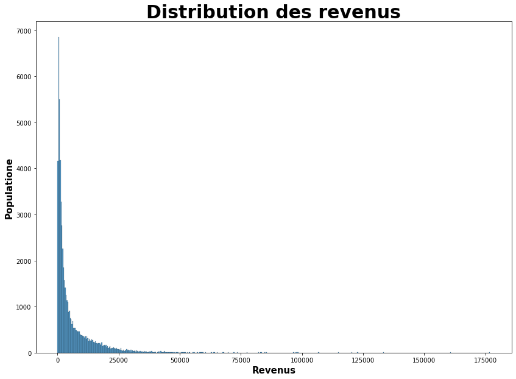

```python
plt.figure(figsize = (14,10))
sns.histplot(data_train.income)
plt.title("Distribution des revenus" , fontsize = 30, fontweight = "bold")
plt.xlabel("Revenus", fontsize = 15, fontweight = "bold")
plt.ylabel("Populatione", fontsize = 15, fontweight = "bold")
plt.savefig(save + r"\04_hist_revenus.png")
plt.show()
```

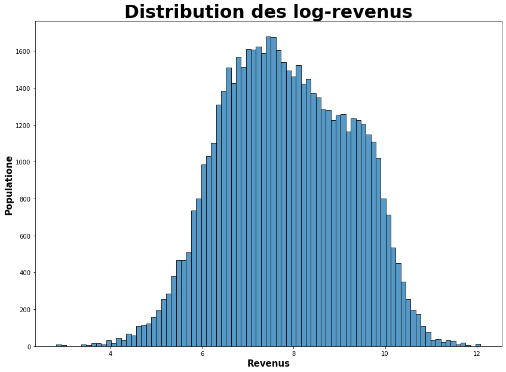

```python
plt.figure(figsize = (14,10))
sns.histplot(data_train.ln_income)
plt.title("Distribution des log-revenus" , fontsize = 30, fontweight = "bold")
plt.xlabel("Revenus", fontsize = 15, fontweight = "bold")
plt.ylabel("Populatione", fontsize = 15, fontweight = "bold")
plt.savefig(save + r"\04_hist_revenus_log.png")
plt.show()
```

En passant les revenus sous logarithme, les données semblent davantage ordonnées selon une loi normale. Voyons si le test de normalité de Kolmogorov Smirnov valide cette intuition ?

4.1.2.2 Normalité des log-income

```python
# normalité des log-revenus
print(st.ks_2samp(data_train.ln_income, np.random.normal(data_train.ln_income.mean(), data_train.ln_income.std(ddof = 0), len(data_train))))
```

```
KstestResult(statistic=0.035948275862068946, pvalue=5.3728599909440676e-33)
```

Avec une p-value inférieure à 5%, nous rejettons l'hypothèse de normalité des log-income. Nous invalidons la première hypothèse de l'ANOVA des log-revenus. Pour autant, compte-tenu de la nette amélioration du modèle et des graphiques ci-dessus (ainsi que l'amélioration de la p-value), les log-income semblent être davantage "normaux".  
4.1.2.3 Normalité des résidus

```python
st.ks_2samp(anova_pays_ln.resid, np.random.normal(anova_pays_ln.resid.mean(), anova_pays_ln.resid.std(ddof = 0), len(anova_pays_ln.resid)))
```

[output not shown]

Les log-résidus ne sont pas normaux avec une p-value inférieure à 5%, nous rejette cette hypothèse.  
4.1.2.4 Homoscédasticité des résidus

```python
_, pval, __, f_pval = statsmodels.stats.diagnostic.het_breuschpagan(anova_pays_ln.resid, anova_pays_ln.model.exog)
print('p value test Breusch Pagan:', pval)
```

```
p value test Breusch Pagan: 0.0
```

Les résidus ne sont pas homoscédastiques, nous rejette cette hypothèse avec une p-value inférieure à 5%.  
4.1.2.5 Indépendance des variables exogènes vs résidus

```python
col_ln = [variance_inflation_factor(anova_pays_ln.model.exog, i) for i in np.arange(1,anova_pays_ln.model.exog.shape[1])]
print(col_ln)
```

```
[1.9954555579353177, 2.0015099593060612, 2.068065967016491, 2.0720971657028637, 2.0620186335403723, 2.053954522738632, 1.9934372813593202, 2.0297553366174053, 2.1224630541871927, 2.0055458699221798, 2.0579867209252525, 2.0922488755622184, 1.8782775041050896, 1.9974737631184407, 1.9651739130434782, 1…
```

Avec des indices inférieurs à 5, nos variables exogènes (_i.e. sous-échantillons de log-income) ne présentent pas de colinéarité rapprochée.

Malgré la non-validation des hypothèses, l'ANOVA des log-income nous confirme l'intuition que l'ANOVA des income (avec un eta²/R² plus explicatif certes) et de notre seconde partie : les revenus moyens et les distribution de revenus sont indépendantes et varient en fonction des pays.

À présent, nous souhaitons comprendre les facteurs expliquant les revenus, tous pays confondus.  
Nous procédons par **régressions linéaires multiples** pour comprendre les plus déterminants.

Les hypothèses à vérifier sur mes régressions linéaires :

- H1 : Le modèle est bien spécifié en moyenne
- H2 : Homoscédasticité des erreurs (variance constante)
- H3 : Pas d'autocorrélation des erreurs.
- H4 : Les erreurs sont linéairement indépendantes des variables exogènes.
- H5 : Les erreurs suivent une loi normale.

**4.2 Régression linéaire : income = income_mean + gini + $\epsilon$**  
**Normalité des variables explicatives**

Retour au sommaire

```python
# normalité des Ginis
print(st.ks_2samp(data_train.gini, np.random.normal(data_train.gini.mean(), data_train.gini.std(ddof = 0), len(data_train))))

# normalité des revenus moyens
print(st.ks_2samp(data_train.income_mean, np.random.normal(data_train.income_mean.mean(), data_train.income_mean.std(ddof = 0), len(data_train))))

# normalité des classes de revenus des parents
print(st.ks_2samp(data_train.ci_parents, np.random.normal(data_train.ci_parents.mean(), data_train.ci_parents.std(ddof = 0), len(data_train))))
```

```
KstestResult(statistic=0.11768965517241381, pvalue=0.0)
KstestResult(statistic=0.20937931034482754, pvalue=0.0)
KstestResult(statistic=0.06322413793103454, pvalue=3.2043901166793366e-101)
```

Les indices de Gini, les revenus moyens et les classifications parents ne sont pas normales (p-value inférieure à 5% invalidant leur normalité avec le test de Kolmogorov-Smirnov).  
Nous invalidons les premières hypothèses des régressions linéaires. Pour autant, testons les régressions pour déceler d'éventuellles tendances.  
**4.2.1 Régression des income non-log**

Retour au sommaire

```python
reg_inc = smf.ols('income~income_mean+gini', data=data_train).fit()
print(reg_inc.summary())
```

```
                            OLS Regression Results
==============================================================================
Dep. Variable:                 income   R-squared:                       0.491
Model:                            OLS   Adj. R-squared:                  0.491
Method:                 Least Squares   F-statistic:                 2.798e+04
Date:                Wed, 21 Jul 2021   Prob (F-statistic):               0.00
Time:                        19:47:51   Log-Likelihood:            -5.9383e+05
No. Observations:               58000   AIC:                         1.188e+06
Df Residuals:                   57997   BIC:                         1.188e+06
Df Model:                           2
Covariance Type:            nonrobust
===============================================================================
                  coef    std err          t      P>|t|      [0.025      0.975]
-------------------------------------------------------------------------------
Intercept     -38.6601    152.371     -0.254      0.800    -337.307     259.987
income_mean     1.0052      0.005    222.941      0.000       0.996       1.014
gini            0.2266      3.675      0.062      0.951      -6.976       7.430
==============================================================================
Omnibus:                    73507.537   Durbin-Watson:                   2.008
Prob(Omnibus):                  0.000   Jarque-Bera (JB):         21894429.024
Skew:                           6.808   Prob(JB):                         0.00
Kurtosis:                      97.204   Cond. No.                     4.86e+04
==============================================================================

Notes:
[1] Standard Errors assume that the covariance matrix of the errors is correctly specified.
[2] The condition number is large, 4.86e+04. This might indicate that there are
strong multicollinearity or other numerical problems.
```

Retour au sommaire

```python
reg_inc_ln = smf.ols('ln_income~ln_income_mean+ln_gini', data=data_train).fit()
print(reg_inc_ln.summary())
```

```
                            OLS Regression Results
==============================================================================
Dep. Variable:              ln_income   R-squared:                       0.725
Model:                            OLS   Adj. R-squared:                  0.725
Method:                 Least Squares   F-statistic:                 7.646e+04
Date:                Wed, 21 Jul 2021   Prob (F-statistic):               0.00
Time:                        19:47:52   Log-Likelihood:                -63550.
No. Observations:               58000   AIC:                         1.271e+05
Df Residuals:                   57997   BIC:                         1.271e+05
Df Model:                           2
Covariance Type:            nonrobust
==================================================================================
                     coef    std err          t      P>|t|      [0.025      0.975]
----------------------------------------------------------------------------------
Intercept          2.2236      0.065     34.366      0.000       2.097       2.350
ln_income_mean     0.9834      0.003    356.963      0.000       0.978       0.989
ln_gini           -0.6541      0.015    -43.491      0.000      -0.684      -0.625
==============================================================================
Omnibus:                     3791.863   Durbin-Watson:                   1.996
Prob(Omnibus):                  0.000   Jarque-Bera (JB):            17079.266
Skew:                          -0.138   Prob(JB):                         0.00
Kurtosis:                       5.644   Cond. No.                         198.
==============================================================================

Notes:
[1] Standard Errors assume that the covariance matrix of the errors is correctly specified.
```

4.2.2.1 Normalité des résidus

```python
st.ks_2samp(reg_inc_ln.resid, np.random.normal(reg_inc_ln.resid.mean(), reg_inc_ln.resid.std(ddof = 0), len(anova_pays_ln.resid)))
```

```
KstestResult(statistic=0.04100000000000001, pvalue=8.527125938616581e-43)
```

Avec une p-value proche de zéro, nous rejettons l'hypothèse de normalité des résidus ($H_0$).  
Testons maintenant l'homoscédasticité des résidus avec le test de Breusch-Pagan.  
Le test se décline comme suit : $\begin{cases} H_{0} : \forall j \in [|0, 116|] \ \sigma^{2}_{j} (résidus) = \sigma^{2}_{échantillon} (résidus) \\ H_{1} : \exists \ i\neq j \ tel \ que, \forall j \in [|0, 116|] \ \sigma^{2}_{i} \neq \sigma^{2}_{j} \end{cases}$  
4.2.2.2 Homoscédasticité des résidus

```python
_, pval, __, f_pval = statsmodels.stats.diagnostic.het_breuschpagan(reg_inc_ln.resid, reg_inc_ln.model.exog)
print('p value test Breusch Pagan:', pval)
```

```
p value test Breusch Pagan: 0.0
```

Les résidus ne sont pas homoscédastiques (les résidus associés aux différentes variables exogènes ont des variances significativement différentes), nous invalidons cette hypothèse avec une p-value inférieure à 5%.

4.2.2.3 Indépendance entre variables exogènes et résidus

```python
col_reg_inc_ln = [variance_inflation_factor(reg_inc_ln.model.exog, i) for i in np.arange(1,reg_inc_ln.model.exog.shape[1])]
print(col_reg_inc_ln)
```

```
[1.1019902119297427, 1.1019902119297453]
```

```python
# je confirme avec pearsonr si j'ai bien une absence de correl
from scipy.stats import pearsonr as pea

print(pea(data_train.ln_income_mean, reg_inc_ln.resid)[0])
print(pea(data_train.ln_gini, reg_inc_ln.resid)[0])
```

```
-2.2476595237796992e-15
1.9199052070373313e-15
```

```python
reg_inc_ln.params
```

```
Intercept         2.223552
ln_income_mean    0.983403
ln_gini          -0.654074
dtype: float64
```

**4.2.3 Conclusions du modèle**  
Compte-tenu des coefficients associés aux log-income_mean et log-gini, plus le niveau de revenu du pays moyen augmente, plus les chances d'avoir un haut revenu de mes prospects augmentent. Au même titre, plus le gini d'un pays augmente, plus les revenus ont tendance à diminuer, plus les chances d'avoir un haut revenu de mes prospects diminuent.  
Nous notons ici la différence de poids entre ln_income_mean et ln_gini. Les income sont sensiblement plus grands que les gini dans leur ordre de grandeur. Par conséquent, les principaux facteurs ici demeurent les niveaux de revenus moyens.

Nous souhaitons maintenant améliorer notre modèle en rajoutant une variable explicative : la classification parents (**$c_{i,parents}$**).  
**4.3 Régression : income = income_mean + gini + $c_{i}(parents)$ + $\epsilon$**  
4.3.1 Régression des income non-log

Retour au sommaire

```python
reg_new = smf.ols('income~income_mean+gini+ci_parents', data=data_train).fit()
print(reg_new.summary())
```

```
                            OLS Regression Results
==============================================================================
Dep. Variable:                 income   R-squared:                       0.542
Model:                            OLS   Adj. R-squared:                  0.542
Method:                 Least Squares   F-statistic:                 2.285e+04
Date:                Wed, 21 Jul 2021   Prob (F-statistic):               0.00
Time:                        19:47:52   Log-Likelihood:            -5.9079e+05
No. Observations:               58000   AIC:                         1.182e+06
Df Residuals:                   57996   BIC:                         1.182e+06
Df Model:                           3
Covariance Type:            nonrobust
===============================================================================
                  coef    std err          t      P>|t|      [0.025      0.975]
-------------------------------------------------------------------------------
Intercept   -3870.7474    152.303    -25.415      0.000   -4169.262   -3572.232
income_mean     1.0065      0.004    235.232      0.000       0.998       1.015
gini            2.6563      3.487      0.762      0.446      -4.179       9.492
ci_parents     73.9063      0.923     80.073      0.000      72.097      75.715
==============================================================================
Omnibus:                    75340.034   Durbin-Watson:                   2.010
Prob(Omnibus):                  0.000   Jarque-Bera (JB):         25895845.504
Skew:                           7.084   Prob(JB):                         0.00
Kurtosis:                     105.542   Cond. No.                     5.12e+04
==============================================================================

Notes:
[1] Standard Errors assume that the covariance matrix of the errors is correctly specified.
[2] The condition number is large, 5.12e+04. This might indicate that there are
strong multicollinearity or other numerical problems.
```

Nous passons les variables au log pour observer une amélioration du modèle.  
4.3.2 Régression des log-income

Retour au sommaire

```python
reg_new_log = smf.ols('ln_income~ln_income_mean+ln_gini+ln_ci_parents', data=data_train).fit()
print(reg_new_log.summary())
```

```
                            OLS Regression Results
==============================================================================
Dep. Variable:              ln_income   R-squared:                       0.798
Model:                            OLS   Adj. R-squared:                  0.798
Method:                 Least Squares   F-statistic:                 7.646e+04
Date:                Wed, 21 Jul 2021   Prob (F-statistic):               0.00
Time:                        19:47:52   Log-Likelihood:                -54578.
No. Observations:               58000   AIC:                         1.092e+05
Df Residuals:                   57996   BIC:                         1.092e+05
Df Model:                           3
Covariance Type:            nonrobust
==================================================================================
                     coef    std err          t      P>|t|      [0.025      0.975]
----------------------------------------------------------------------------------
Intercept          0.6883      0.056     12.196      0.000       0.578       0.799
ln_income_mean     0.9839      0.002    416.873      0.000       0.979       0.988
ln_gini           -0.6356      0.013    -49.328      0.000      -0.661      -0.610
ln_ci_parents      0.4028      0.003    145.007      0.000       0.397       0.408
==============================================================================
Omnibus:                     2192.150   Durbin-Watson:                   1.993
Prob(Omnibus):                  0.000   Jarque-Bera (JB):             6590.800
Skew:                           0.075   Prob(JB):                         0.00
Kurtosis:                       4.645   Cond. No.                         217.
==============================================================================

Notes:
[1] Standard Errors assume that the covariance matrix of the errors is correctly specified.
```

4.3.2.1 Normalité des résidus

```python
st.ks_2samp(reg_new_log.resid, np.random.normal(reg_new_log.resid.mean(), reg_new_log.resid.std(ddof = 0), len(reg_new_log.resid)))
```

```
KstestResult(statistic=0.023706896551724088, pvalue=1.3671466650865803e-14)
```

Avec une p-value proche de zéro je rejette l'hypothèse de normalité de mes résidus ($H_0$).  
Je fais maintenant le test de Breusch-Pagan sur l'homoscédasticité des revenus de mes différents pays.  
Le test se décline comme suit : $\begin{cases} H_{0} : \forall j \in [|0, 116|] \ \sigma^{2}_{j} (résidus) = \sigma^{2}_{échantillon} (résidus) \\ H_{1} : \exists \ i\ tel \ que, \forall j \in [|0, 116|] \ \sigma^{2}_{i} \neq \sigma^{2}_{j} \end{cases}$  
4.3.2.2 Homoscédasticité des résidus

```python
_, pval, __, f_pval = statsmodels.stats.diagnostic.het_breuschpagan(reg_new_log.resid, reg_new_log.model.exog)
print('p value test Breusch Pagan:', pval)
```

```
p value test Breusch Pagan: 0.0
```

Les résidus ne sont pas homoscédastiques (la variance des résidus associés à chaque variable exogène est significativement différente). Nous rejetton cette hypothèse avec une p-value inférieure à 5%

4.3.2.3 Indépendance entre variables exogènes et résidus

```python
col_reg_new_log = [variance_inflation_factor(reg_new_log.model.exog, i) for i in np.arange(1,reg_new_log.model.exog.shape[1])]
print(col_reg_new_log)
```

```
[1.1019922699028006, 1.102098296193536, 1.0001010677630517]
```

```python
from scipy.stats import pearsonr as pea

# je confirme avec des coefficients de pearson le variance_inflation_factor
print(pea(reg_new_log.resid, data_train.ln_income_mean)[0])
print(pea(reg_new_log.resid, data_train.ln_gini)[0])
print(pea(reg_new_log.resid, data_train.ln_ci_parents)[0])
```

```
-1.1548596280663848e-14
2.0326622329758237e-15
-1.5300261058115439e-15
```

Avec des indices inférieurs à 5 et des coefficients de Pearson proche de zéro, nous déduisons que nos résidus sont indépendants de leurs variables exogènes respectives (**log-income_mean**, des **log-gini** et des **log_ci_parents**.

4.3.2.4 Conclusion de la log-régression  
Malgré la non-validation de toutes les hypothèses de la régression linéaire, ce modèle explique à 79.9% les log-revenus enfants par les log-gini des pays dans lesquels ils se trouvent, les log-revenus moyens des pays où ils se trouvent et des log-ci_parents, comme intuité dans la seconde partie de ce notebook.

Compte-tenu des coefficients associés aux log-income_mean, log-gini et log-ci_parents :

- plus le niveau de revenu du pays moyen augmente, plus les revenus ont tendance à augmenter, plus les chances d'avoir un haut revenu de mes prospects augmentent
- plus le gini d'un pays augmente, plus les revenus ont tendance à diminuer (se concentrer vers le bas), plus les chances d'avoir un haut revenu de mes prospects diminuent.
- plus la classification parents augmente, plus les revenus enfant ont tendance à augmenter, plus les chances d'avoir un haut revenu de mes prospects augmentent.

4.3.3 Conclusions du modèle  
Nous notons ici la différence de poids entre ln_income_mean, ln_gini et ln_ci_parents. Les income sont sensiblement plus grands que les gini et les classifications parents dans leur ordre de grandeur. Par conséquent, les principaux facteurs explicatifs demeurent ici les niveaux de revenus moyens, auxquels nous pouvons ajouter dans une mesure plus modérée les indices de Gini et la connaissance de la classe de revenus des parents.  
Compte-tenu du coefficient de mobilité de chaque pays, il est manifeste que connaître la classification des revenus parents, au sein-même d'un pays, est plus intéressant que l'indice de Gini en tant que tel. Il est possible de tirer plus de profit dans un pays à fort Gini au sein des classes plus élevées et que dans un pays à faible Gini avec une classification parents inconnue, à niveau de revenu inclassable.

```python
reg_new_log.params
```

```
Intercept         0.688277
ln_income_mean    0.983871
ln_gini          -0.635571
ln_ci_parents     0.402821
dtype: float64
```

Pour la curiosité et la beauté de l'essai, nous essayons cette fois-ci de trouver des relations avec les mêmes variables, mais sans passer la classifications parents au logarithme.  
**4.4 Essai sans conclusion**

Retour au sommaire

```python
print(smf.ols('ln_income~ln_income_mean+ln_gini+ci_parents', data=data_train).fit().summary())
```

```
                            OLS Regression Results
==============================================================================
Dep. Variable:              ln_income   R-squared:                       0.805
Model:                            OLS   Adj. R-squared:                  0.805
Method:                 Least Squares   F-statistic:                 8.002e+04
Date:                Wed, 21 Jul 2021   Prob (F-statistic):               0.00
Time:                        19:47:52   Log-Likelihood:                -53520.
No. Observations:               58000   AIC:                         1.070e+05
Df Residuals:                   57996   BIC:                         1.071e+05
Df Model:                           3
Covariance Type:            nonrobust
==================================================================================
                     coef    std err          t      P>|t|      [0.025      0.975]
----------------------------------------------------------------------------------
Intercept          1.4902      0.055     27.277      0.000       1.383       1.597
ln_income_mean     0.9830      0.002    424.162      0.000       0.978       0.988
ln_gini           -0.6396      0.013    -50.552      0.000      -0.664      -0.615
ci_parents         0.0136   8.75e-05    154.802      0.000       0.013       0.014
==============================================================================
Omnibus:                     3376.634   Durbin-Watson:                   1.995
Prob(Omnibus):                  0.000   Jarque-Bera (JB):            12440.783
Skew:                          -0.190   Prob(JB):                         0.00
Kurtosis:                       5.237   Cond. No.                     1.30e+03
==============================================================================

Notes:
[1] Standard Errors assume that the covariance matrix of the errors is correctly specified.
[2] The condition number is large, 1.3e+03. This might indicate that there are
strong multicollinearity or other numerical problems.
```

Nous tentons ici d'expliquer les log-revenus des prospects en fonction des log-income moyens, des log-gini et des classifications parents **non-log**. Au regard du $R²$, ce modèle semble expliquer 80.5% des données avec des variables exogènes significatives. Cependant, il ne semble pas judicieux d'intégrer les classes parents non-log, dans un soucis de rigueur. Par conséquent, nous ne pouvons rien conclure en dehors d'une simple apparence d'un modèle explicatif plus efficace que les précédents, mais moins conhérent mathématiquement.

Retour au sommaire